# Flexible vocal timing adaptation to predictable and unpredictable playback noise

Ava Kiai

### About

In this experiment, we played amplitude modulated white noise to a group of bats in order to investigate their ability to temporally modulate their calling behavior at the group level.

We hypothesized that bats would adapt the timing of their calls to avoid temporal overlap with the amplitude modulated noise.

After extracting call timings from acoustic recordings (.wav files) and identifying the instantaneous period (or phase) in the real or simulated (as in the silent condition) amplitude modulation cycle, we analyzed the call onset data, primarily with circular statistics.

### Setup

```r
packages <- c("circular", "CircStats", "CircSpaceTime", "sjPlot", "janitor", "broom", "knitr",  "kableExtra", "car", "MASS", "emmeans", "rcompanion", "pscl", "caret", "MLeval", "viridis", "scales","ggh4x","ggside", "ggdist", "ggridges","tidyverse")

# Install packages not yet installed
installed_packages <- packages %in% rownames(installed.packages())
if (any(installed_packages == FALSE)) {
  install.packages(packages[!installed_packages])
}

# Packages loading
invisible(lapply(packages, library, character.only = TRUE))
```

### Parameters

```r
str(params)
```

```
## List of 7
##  $ subsample   : logi FALSE
##  $ data_path   : chr "./../1-data"
##  $ results_path: chr "./../3-results"
##  $ exp         : chr "exp_2"
##  $ plot_sm     : logi TRUE
##  $ use_all     : logi TRUE
##  $ seed        : num 42
```

```r
# local paths
data_path <- params$data_path
results_path <- params$results_path
tables_path <- file.path(results_path,'tables')
  if (!dir.exists(tables_path)) dir.create(tables_path)
figures_path <- file.path(results_path,'figures')
  if (!dir.exists(figures_path)) dir.create(figures_path)
sm_path <- file.path(results_path,'supplementary_figures')
  if (!dir.exists(sm_path)) dir.create(sm_path)

# experiment number
exp <- params$exp

# seed for subsampling
seed <- params$seed

# whether to use all data for circular stats
use_all <- params$use_all
subsample <- params$subsample

# whether to plot supplementary plots/tables
supplementary <- params$plot_sm
```

#### Load data

```r
# load data
data <- readr::read_rds(file.path(data_path,'input',paste0(exp, "_data.RDS"))) %>%
  mutate(start_phase_circ = circular(start_phase,
                                     units="radians",
                                     zero = 0,
                                     modulo = "2pi",
                                     rotation = "counter"),
         .after ="start_phase")

# data for averaging histograms (modulation variable is numeric-ish)
data_2proc <- data %>%
  mutate(modulation = factor(modulation,
                             levels = sort(unique(data$modulation))))

# data for remaining analyses (modulation variable is character-ish, better for plotting)
data <- data %>%
  mutate(modulation = factor(modulation,
                             levels = sort(unique(data$modulation)),
                             labels = paste0(as.character(sort(unique(data$modulation))),"Hz")))

# data from the first few minutes of exposure
data_init <- filter_firstexposure(data_2proc)

str(data)
```

```
## 'data.frame':    1088994 obs. of  23 variables:
##  $ group           : Factor w/ 4 levels "1","2","3","4": 1 1 1 1 1 1 1 1 1 1 ...
##  $ session         : int  1 1 1 1 1 1 1 1 1 1 ...
##  $ part            : int  1 1 1 1 1 1 1 1 1 1 ...
##  $ condition       : Factor w/ 3 levels "silence","steady-state masker",..: 1 1 1 1 1 1 1 1 1 1 ...
##  $ modulation      : Factor w/ 8 levels "4Hz","8Hz","16Hz",..: 3 3 3 3 3 3 3 3 3 3 ...
##  $ minute          : num  1 1 1 1 1 1 1 1 1 1 ...
##  $ start_seconds   : num  0.0151 0.0777 0.1069 0.1599 0.1902 ...
##  $ stop_seconds    : num  0.0169 0.0794 0.1086 0.1627 0.1918 ...
##  $ start_sp        : num  3776 19437 26717 39986 47554 ...
##  $ end_sp          : num  4223 19848 27141 40671 47960 ...
##  $ start_cycle     : int  1 2 2 3 4 4 5 6 7 9 ...
##  $ end_cycle       : int  1 2 2 3 4 4 5 6 7 9 ...
##  $ start_phase     : num  1.518 1.533 4.46 3.513 0.273 ...
##  $ start_phase_circ: 'circular' num  1.518 1.533 4.46 3.513 0.273 ...
```

[output cut: 16 more lines]

```r
# save interim data manips to 1-data/output
data_path <- file.path(data_path,'output')
  if (!dir.exists(data_path)) dir.create(data_path)
```

### Summary Stats

A few rough summary statistics. Note that each row is an observation (call event), with parameters:

- group: experimental group (1:4) (Note that for experiment 1, there were 8 groups of bats tested in each modulation rate context, but each is labelled 1-4.)
- session: recording day (1:5)
- part: experimental block (1:3), silent condition is always part 1
- condition: playback condition
- modulation: amplitude modulation rate for masking conditions
- minute: minute since the start of the recording file in which the call occurred
- start_seconds: timestamps of call onsets in seconds since the start of the file
- stop_seconds: ibid. for call offsets
- start_sp: samples since start of file at call onset
- end_sp: ibid. for call offsets
- start_cycle: nth cycle of the corresponding modulation rate in the corresponding file at call onset
- end_cycle: ibid. at call onset
- start_phase: moment in the corresponding modulation cycle (in radians) at call onset
- start_phase_circ: ibid., but of class circular
- end_phase: ibid. at call offset
- start_per: timepoint in the corresponding modulation period (in seconds) at call onset
- end_per: ibid. at call offset
- duration: call offset - call onset (in seconds)
- onset_interval: call onset - previous call’s call onset (is NA if call is the first in the file)
- class: type of call (for now, all are labelled “call”)
- file_no: index of recording file, indicating the order of recorded files from the corresponding experimental block
- familiarization: number of days in which bats were housed together as a group prior to the first recording day
- order: randomization/counter-balancing order for the presentation of masking conditions

```r
#summary(data)
```

Total number of calls:

```r
nrow(data)
```

```
## [1] 1088994
```

```r
#1,425,067 # exp 1
#1,088,994 # exp 2
# = 2,514,061 # total
```

Call durations:

```r
summary(data$duration)
```

```
##     Min.  1st Qu.   Median     Mean  3rd Qu.     Max.
## 0.000996 0.001716 0.003128 0.003881 0.004364 0.704744
```

```r
IQR(data$duration)
```

```
## [1] 0.002648
```

### Distribution of call onsets in the modulation cycle

Calculate histogram averages (essentially, a PSTH)

```r
call_summary1 <- get_avg_hist(data_2proc, NULL, list("group","session"), "period",
                              by_group = TRUE, by_session = TRUE)
call_summary60 <- get_avg_hist(data_2proc, 60, list("group","session"), "period")

# optionally: check that the two have the correct # of bins
# call_summary1$generic %>% group_by(modulation) %>% summarise(sort(unique(mids),decreasing = T)[2])
# call_summary60$generic %>% group_by(modulation) %>% summarise(n=length(unique(mids)))
```

First, we asked: Did the presence of playback noise affect the distribution of emitted calls within the modulation cycle?

Here we plot an averaged histogram of detected call onsets (binned calls (1 ms bins) summed over all cycles, averaged over groups and recording days):

Points are mean # calls, shaded areas are +- sem…

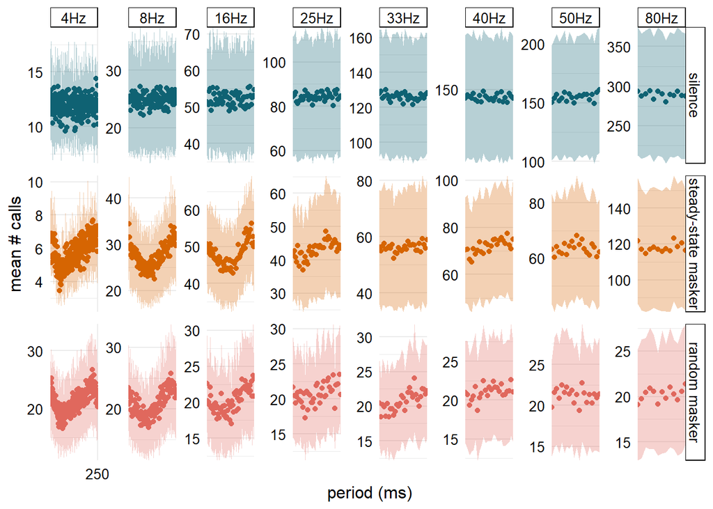

```r
# average call counts all at once, 1 ms bins
p <- p.hist_avg_dot_kwargs(dat = call_summary1$generic, facets = c("condition","modulation"))
 print(p)
```

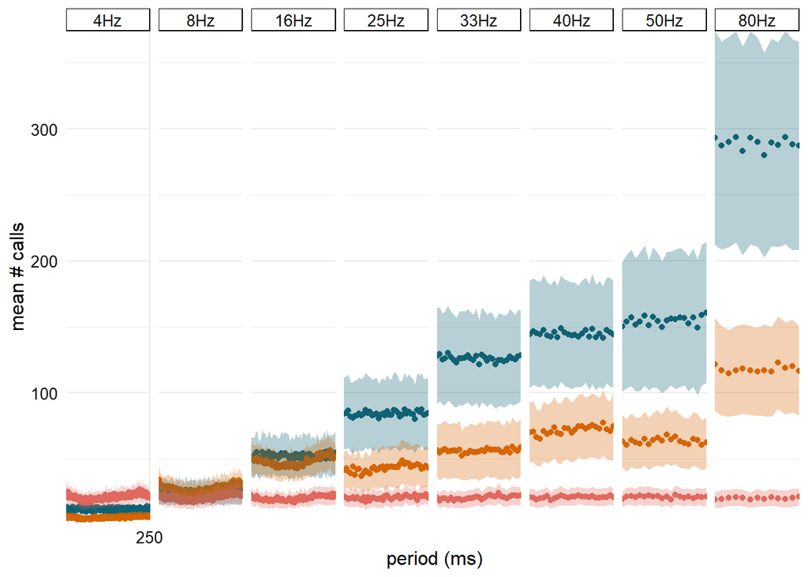

```r
 ggsave(file.path(figures_path,paste0(exp, '_fig2a.png') ), p, width = w, height = 5)

# average call counts with fixed y-axis, to better illustrate the relative calling rate between conditions
p2 <- p.hist_avg_dot_kwargs_fixedy(dat = call_summary1$generic, facets = c("","modulation"))
  print(p2)
```

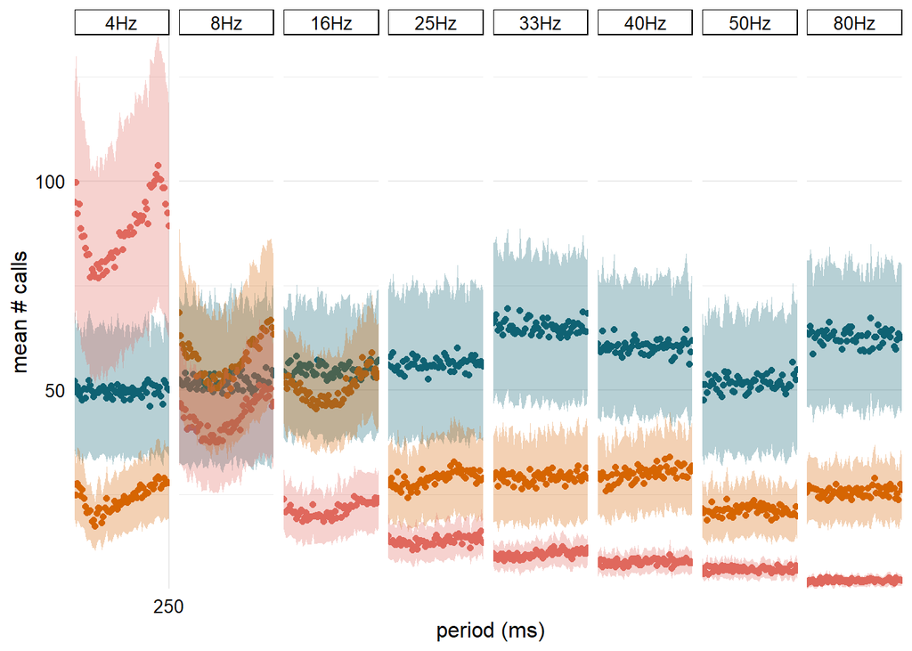

```r
 ggsave(file.path(figures_path,paste0(exp, '_fig2a-alt1.png') ), p2, width = w, height = 5)

# average call counts with fixed y-axis, with 60 ms bins for each modulation rate, to show trend on the same x-scale across conditions
p3 <- p.hist_avg_dot_kwargs_fixedy(dat = call_summary60$generic, facets = c("","modulation"))
  print(p3)
```

```r
  ggsave(file.path(figures_path,paste0(exp, '_fig2a-alt2.png') ), p3, width = w, height = 5)
```

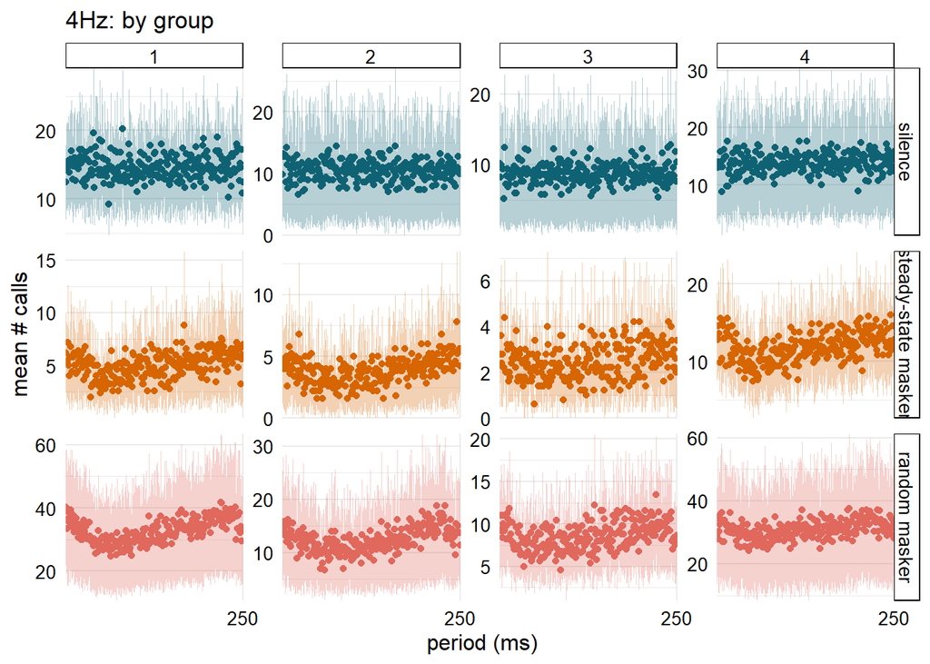

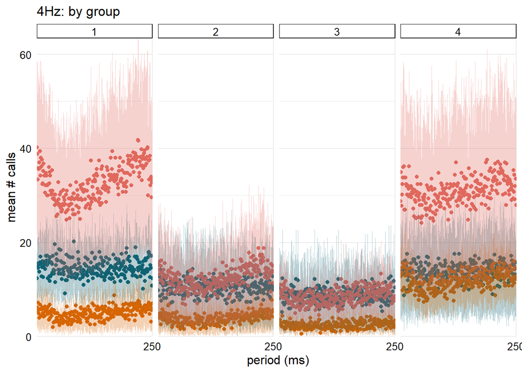

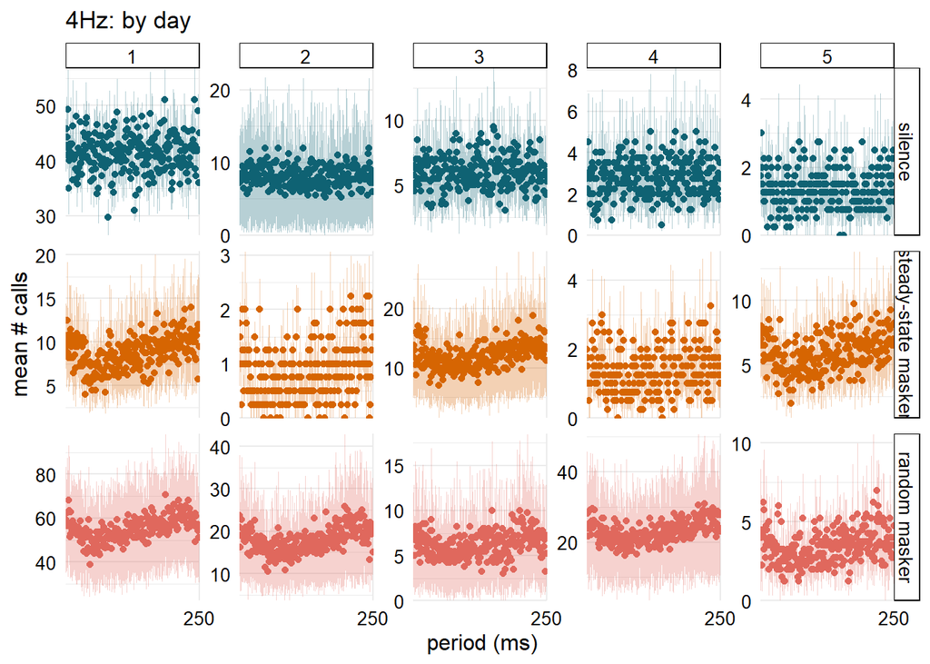

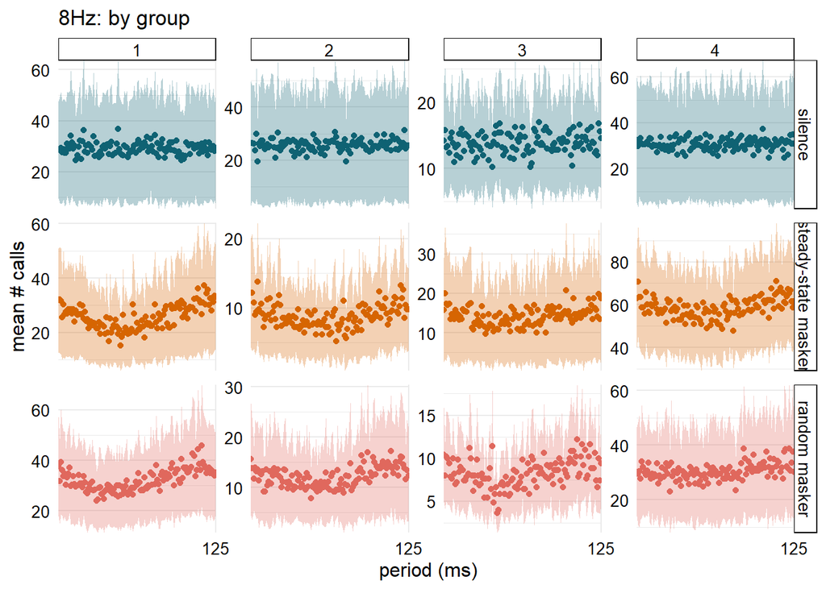

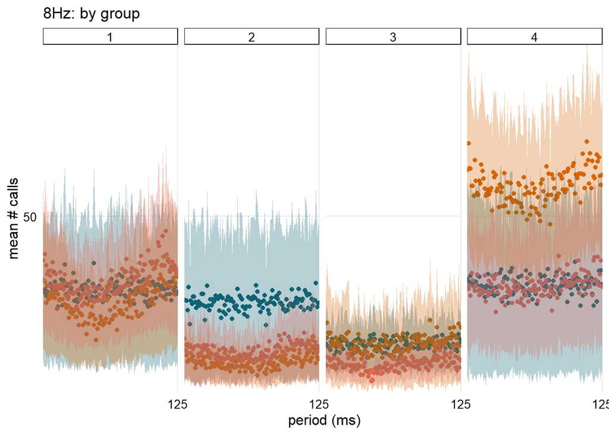

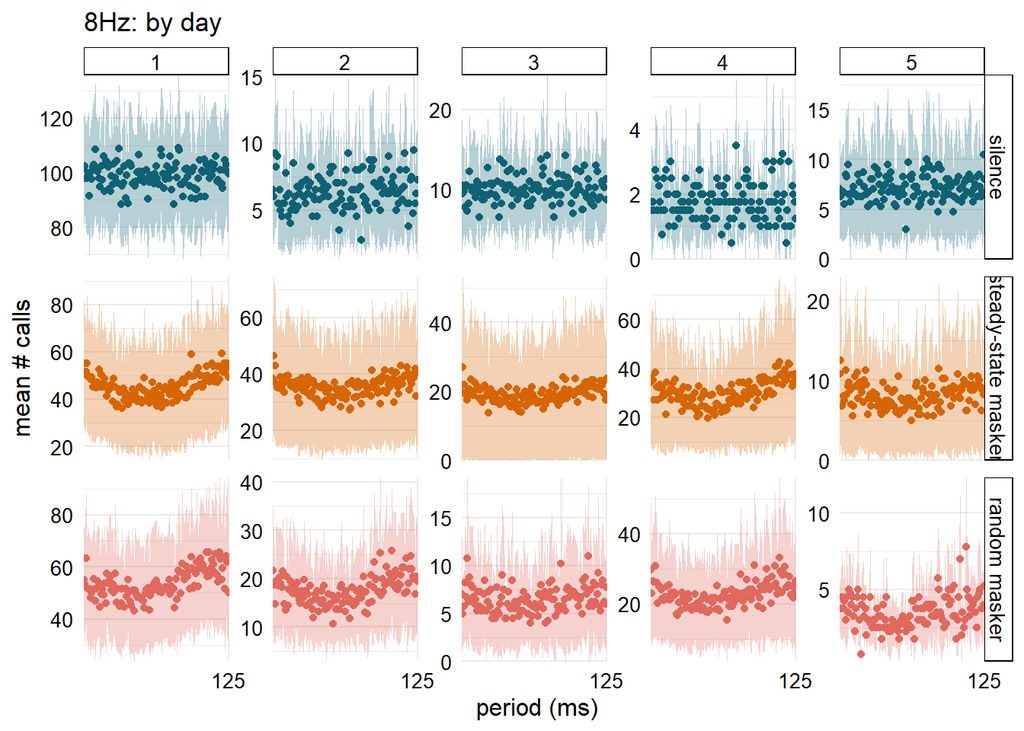

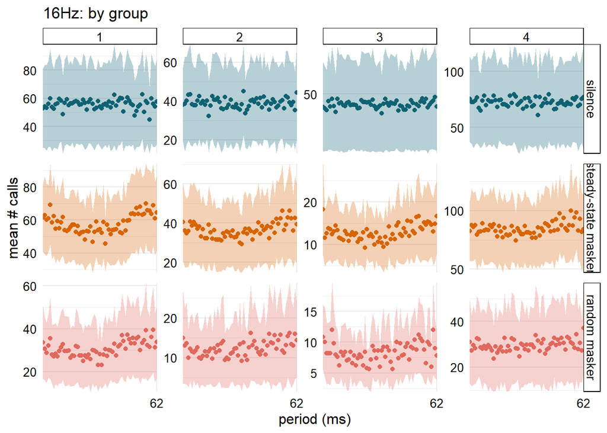

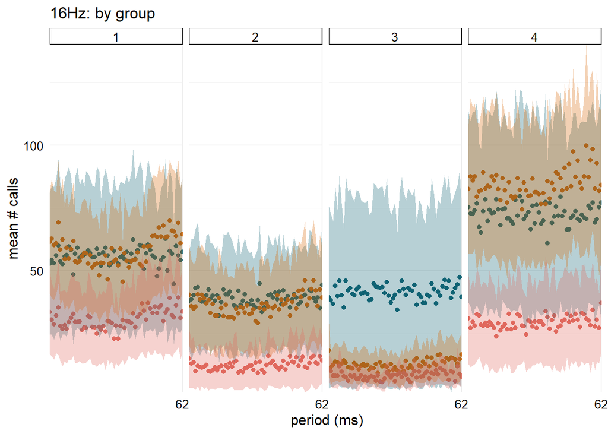

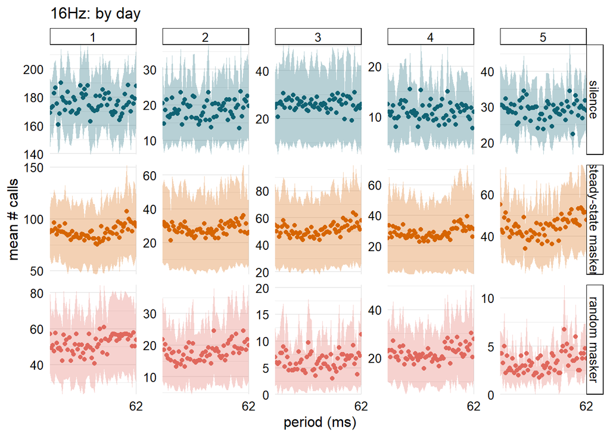

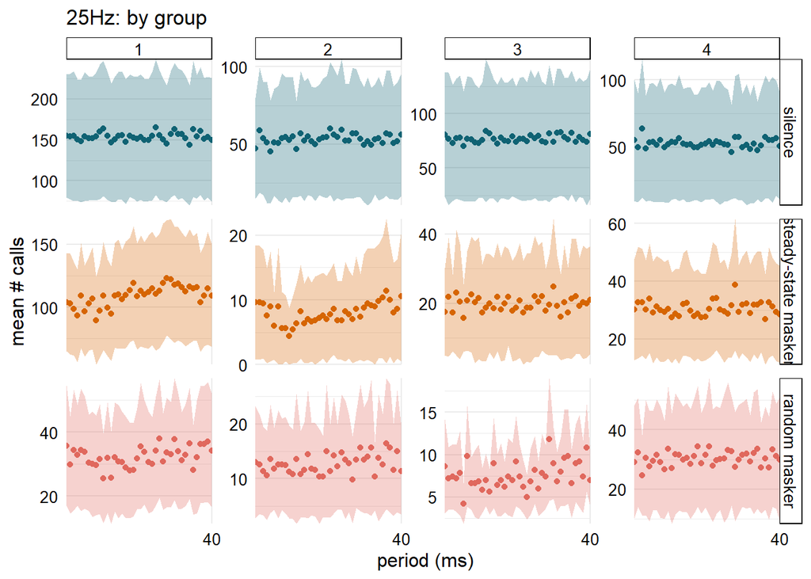

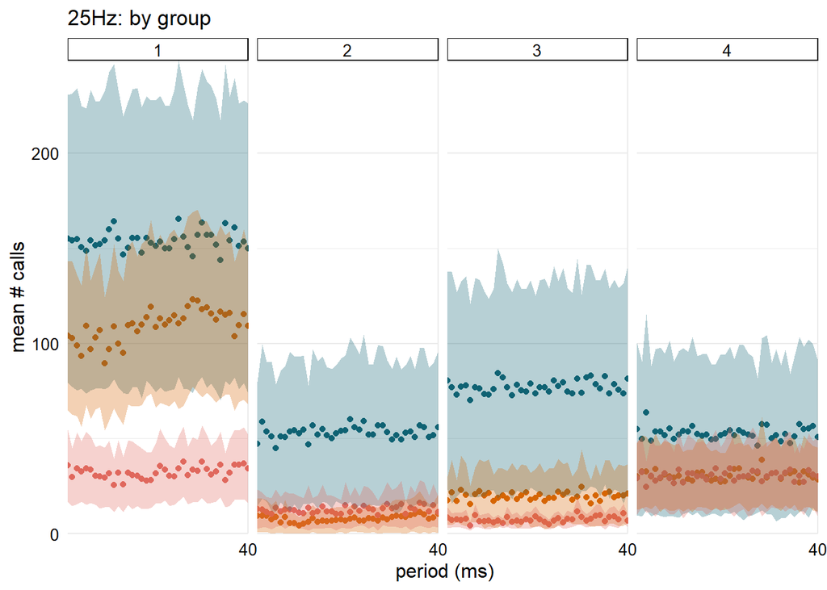

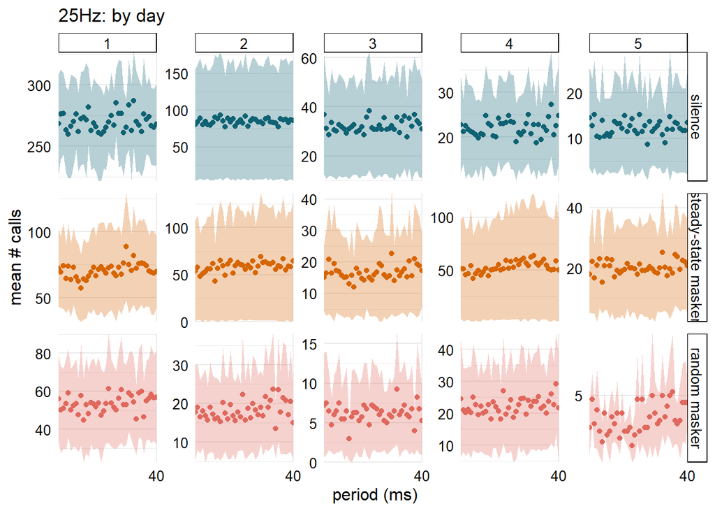

[12 more figures not shown]

```r
# show average call counts (with and without fixed y axis) for each group, and for each recording day ("session")
for (m in sort(unique(call_summary1$group$modulation))) {
 p1 <- p.hist_avg_dot_kwargs(dat = call_summary1$group %>% filter(modulation == m),
                             facets = c("condition","group")) +
                             ggtitle(paste0(m, ": by group"))
 p2 <- p.hist_avg_dot_kwargs_fixedy(dat = call_summary1$group %>% filter(modulation == m),
                                    facets = c("","group")) +
                             ggtitle(paste0(m, ": by group"))
 p3 <- p.hist_avg_dot_kwargs(dat = call_summary1$session %>% filter(modulation == m),
                             facets = c("condition","session")) +
                             ggtitle(paste0(m, ": by day"))

 print(p1); print(p2); print(p3)
 ggsave(file.path(sm_path,paste0(exp, '_figS2_',m,'.png') ),
        p1, width = 7, height = 5)
 ggsave(file.path(sm_path,paste0(exp, '_figS2_',m,'-alt1.png') ),
        p2, width = 7, height = 5)
 ggsave(file.path(sm_path,paste0(exp, '_figS2_',m,'.png') ),
        p3, width = 7, height = 5)
}
```

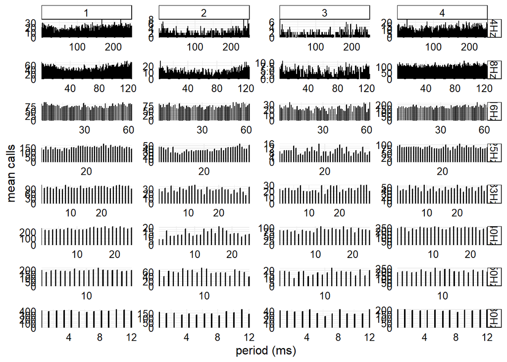

```r
# show average hist of binned calls for the first 7.5-8 mins of continuous AM playback for each mod.
# [not included in paper, but illustrative]
call_summary1_init <- get_avg_hist(data_init, NULL, list("group"), "period", by_group = TRUE)
#str(data_init)

firsts <- p.hist_avg_col(dat = call_summary1_init$group %>%
                 dplyr::filter(condition=="full-band masker" | condition=="steady-state masker"),
               facets = c("modulation","group"))

print(firsts)
```

```r
ggsave(file.path(sm_path,paste0(exp, '_figSx.png') ), firsts, width = 7, height = h2)
```

### Circular Statistics

To analyze the distribution of call onsets within the modulation cycle, we must use circular statistics (with functions from the package `circular`), since the nature of our data is cyclical.

Then, we’ll get bootsrapped mean and concentration parameters from the whole dataset.

We predicted that calls emitted in presence of modulated noise would tend to “cluster” unimodally in the hemisphere corresponding to the amplitude trough. Conversely, we predicted that the distribution of call onsets emitted in silence would show no clustering, and therefore resemble a uniform distribution.

This prediction entails two specific hypotheses:

1. Distribution of calls detected in silence will be equivalent to a uniform distribution, while that of calls detected in the presence of masking noise will deviate from the uniform distribution. –> Method: Rayleigh test of uniformity (`circular::rayleigh.test(x, mu=circular(0))`)
2. The distribution of calls in the playback conditions will each besignificantly different from the silence condition. –> Method: Mardia-Watson-Wheeler non-parametric test of homogeneous samples (`circular::watson.wheeler.test(x,y)`), where differences between samples can be in either the mean or the variance.

#### Calculate summary and distribution statistics

**In which conditions were call onset distributions unimodally clustered?**

```r
# prepare data for analysis: split into lists, one for each modulation x condition case
# data is subsampled if requested in header

data_split <-  data_samp %>% group_by(modulation, condition) %>% group_split()

# label and convert to circular data
circ_data <- lapply(data_split, function(x)
  list(modulation = unique(x$modulation),
       condition = unique(x$condition),
       phase = x$start_phase_circ))


if (file.exists(f_circsum)) { # as RDS...
  circ_summary <- readr::read_rds(f_circsum)

} else {
  # calculate values:
  circ_datsum <- lapply(circ_data,
         function(x) tibble(modulation = x$modulation,
                            condition = x$condition,
                            n = length(x$phase),
                            theta_bar = mean.circular(x$phase, na.rm = T), # angular mean
                            r_bar = rho.circular(x$phase, na.rm = T), # mean resultant length
                            vm = var.circular(x$phase),
                            v = sd.circular(x$phase),
                            # Test of uniformity:
                            rt = rayleigh.test(x$phase, mu=circular(0))$statistic,
                            p = rayleigh.test(x$phase, mu=circular(0))$p.value,
                            # MLE von Mises:
                            mle_mu = mle.vonmises(x$phase)$mu,
                            bs_mu_ci_l = mle.vonmises.bootstrap.ci(x$phase, alpha=.05)$mu.ci[1],
                            bs_mu_ci_h = mle.vonmises.bootstrap.ci(x$phase, alpha=.05)$mu.ci[2],
                            mle_kappa = mle.vonmises(x$phase)$kappa)
                        )

  # wrangle & correct p values
  circ_summary <- tibble(do.call(rbind,circ_datsum))  %>%
                  mutate(p_adjust = p.adjust(p, method ="bonferroni"), .after = "p") %>%
                  mutate(across(where(is.numeric), round, 3))

  head(circ_summary)

  # save, if first time
  if (subsample) {
    readr::write_rds(circ_summary, file = file.path(data_path,paste0("prc_", exp, "_circ_dat-seed",seed,".RDS")))
  } else {
    readr::write_rds(circ_summary, file = file.path(data_path,paste0("prc_", exp, "_circ_dat-all.RDS")))
  }

}

circ_summary
```

```
## # A tibble: 24 × 14
##    modulation condition                n theta_bar  r_bar    vm     v    rt     p p_adjust mle_mu     bs_mu_ci_l bs_mu_ci_h mle_kappa
##    <fct>      <fct>                <dbl> <circular> <dbl> <dbl> <dbl> <dbl> <dbl>    <dbl> <circular> <circular> <circular>     <dbl>
##  1 4Hz        silence              59635 6.203      0.003 0.997  3.39 0.003 0.134        1 6.203      4.207      1.704          0.006
##  2 4Hz        steady-state masker  28938 5.246      0.074 0.926  2.28 0.038 0            0 5.246      5.132      5.353          0.148
##  3 4Hz        random masker       105990 5.245      0.054 0.946  2.42 0.027 0            0 5.245      5.165      5.326          0.108
##  4 8Hz        silence              62203 5.480      0.002 0.998  3.46 0.002 0.27         1 5.480      2.943      2.224          0.005
##  5 8Hz        steady-state masker  65446 5.795      0.057 0.943  2.40 0.05  0            0 5.795      5.699      5.890          0.114
##  6 8Hz        random masker        51939 5.459      0.061 0.939  2.37 0.041 0            0 5.459      5.366      5.567          0.122
##  7 16Hz       silence              65769 0.858      0.003 0.997  3.38 0.002 0.213        1 0.858      5.194      3.164          0.007
##  8 16Hz       steady-state masker  60482 5.732      0.042 0.958  2.52 0.036 0            0 5.732      5.610      5.851          0.084
##  9 16Hz       random masker        25543 5.376      0.046 0.954  2.49 0.028 0            0 5.376      5.178      5.571          0.091
## 10 25Hz       silence              67403 4.819      0.003 0.997  3.37 0     0.448        1 4.819      2.495      1.907          0.007
## # … with 14 more rows
```

#### Plot circular call density

Now, let’s plot our call count data (as a density rather than raw call count) as before, but on the polar plane and indicate the mean direction and resultant length of the resultant vector.

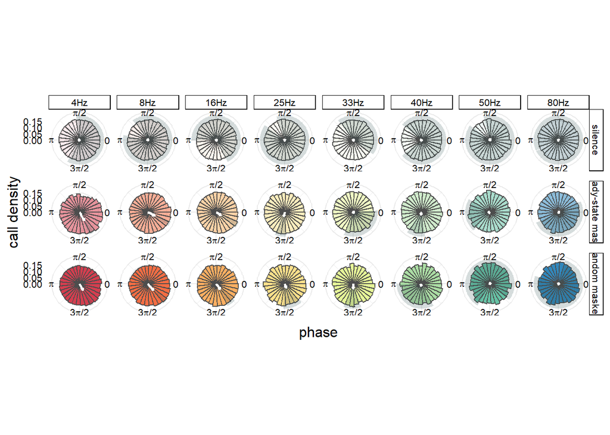

```r
circ_density <- p.circ_density(dat = data_samp, circ_dat = circ_summary_plot, bins = 30) %>% recolor(which="f")

circ_density
```

```r
if (subsample) {
  ggsave(file.path(figures_path,paste0(exp, "_fig2b_",seed,".png")), circ_density, width = w, height = 5)
} else {
  ggsave(file.path(figures_path,paste0(exp, '_fig2b.png')), circ_density, width = w, height = 5)
}
```

#### Calculate bootstrapped angular vectors

**How consistent was the clustering, if present?**

#### Plot bs parameters in the polar plane

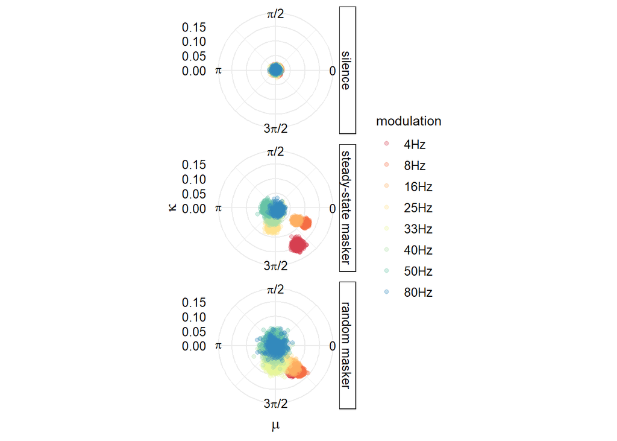

```r
circ_params <- p.circ_params(mu_bs_df, compress = T)  %>% recolor()


circ_params
```

```r
ggsave(file.path(figures_path,paste0(exp, '_fig2c.png')), circ_params, width = 3, height = 6)
```

##### … and in the cartesian plane

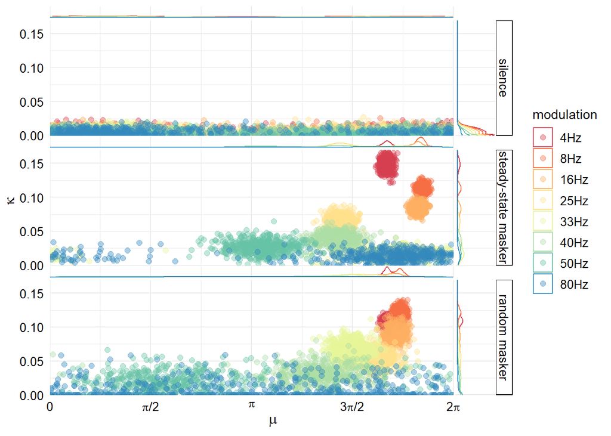

```r
mu_kappa <- p.mu_kappa(dat = mu_bs_df %>%
                         group_by(modulation, condition) %>%
                         slice_sample(n = 500)) %>% recolor()
mu_kappa
```

```r
ggsave(file.path(figures_path,paste0(exp, '_figS3-500.png') ), mu_kappa, width = 6, height = 6)
```

#### [Mardia]-Watson-Wheeler Homogeneity of Samples

We now compute frequentist non-parametric analyses for whether the distributions of calls observed in our different modulation and masking conditions are identical.

The null hypothesis is that the distributions are identical, either in their means or their variances:

##### Compare playback conditions within modulation rate contexts

**Did distributions of call onsets differ between playback conditions at each modulation rate?**

```r
circ_data_df <- do.call(rbind, lapply(circ_data, function(x) as.data.frame(x)))

ww_tests <- lapply(sort(unique(circ_data_df$modulation)), function(x)
  watson.wheeler.test(phase ~ condition,circ_data_df[circ_data_df$modulation==x,]) %>%
    broom::tidy() %>%
     mutate(across(where(is.numeric), round, 3)) %>%
      mutate(modulation = x,.before=1)) %>%
  do.call(rbind,.) %>%
  mutate(p.adjust = p.adjust(p.value, method ="bonferroni"), .after = "p.value") %>%
  janitor::clean_names()

ww_tests
```

```
## # A tibble: 8 × 6
##   modulation statistic p_value p_adjust parameter method
##   <fct>          <dbl>   <dbl>    <dbl>     <dbl> <chr>
## 1 4Hz           282.     0        0             4 Watson-Wheeler test for homogeneity of angles
## 2 8Hz           274.     0        0             4 Watson-Wheeler test for homogeneity of angles
## 3 16Hz          143.     0        0             4 Watson-Wheeler test for homogeneity of angles
## 4 25Hz           45.4    0        0             4 Watson-Wheeler test for homogeneity of angles
## 5 33Hz           32.7    0        0             4 Watson-Wheeler test for homogeneity of angles
## 6 40Hz           20.6    0        0             4 Watson-Wheeler test for homogeneity of angles
## 7 50Hz            8.78   0.067    0.536         4 Watson-Wheeler test for homogeneity of angles
## 8 80Hz            2.29   0.683    1             4 Watson-Wheeler test for homogeneity of angles
```

#### Rao’s test of homogeneity of means, dispersions

Test if means or vector lengths were significantly different between conditions and, separately, across modulation rates:

#### Compare playback conditions within each modulation rate

**How did distributions of call onsets differ between playback conditions at each modulation rate?** **In their angular means or their polar concentrations?**

```r
rao_testsm <- do.call(rbind, lapply(sort(unique(circ_data_df$modulation)), function(x) {
    df <- circ_data_df[circ_data_df$modulation==x,] %>% group_split(condition)
    rao <- circular::rao.test(lapply(df,'[[', 'phase'))
    data.frame(modulation = as.factor(x),
               test = as.factor(c("polar vectors", "dispersions")),
               statistic = rao$statistic, df = rao$df, p_value = rao$p.value) %>%
      mutate(across(where(is.numeric), round, 3)) %>%
      mutate(p_adjust = p.adjust(p_value, method ="bonferroni"), .after = "p_value")
    }))

# test differences for playback conditions within mod rates
rao_testsm
```

```
##    modulation          test statistic df p_value p_adjust
## 1         4Hz polar vectors     3.110  2   0.211    0.422
## 2         4Hz   dispersions   232.370  2   0.000    0.000
## 3         8Hz polar vectors    18.883  2   0.000    0.000
## 4         8Hz   dispersions   199.932  2   0.000    0.000
## 5        16Hz polar vectors     6.895  2   0.032    0.064
## 6        16Hz   dispersions    77.400  2   0.000    0.000
## 7        25Hz polar vectors     3.853  2   0.146    0.292
## 8        25Hz   dispersions    22.588  2   0.000    0.000
## 9        33Hz polar vectors     1.668  2   0.434    0.868
## 10       33Hz   dispersions     7.870  2   0.020    0.040
## 11       40Hz polar vectors     0.897  2   0.639    1.000
## 12       40Hz   dispersions     7.848  2   0.020    0.040
## 13       50Hz polar vectors     0.106  2   0.948    1.000
## 14       50Hz   dispersions     2.521  2   0.284    0.568
## 15       80Hz polar vectors     0.806  2   0.668    1.000
## 16       80Hz   dispersions     0.492  2   0.782    1.000
```

```r
rao_testsc <- do.call(rbind, lapply(sort(unique(circ_data_df$condition)), function(x) {
    df <- circ_data_df[circ_data_df$condition==x,] %>% group_split(modulation)
    rao <- circular::rao.test(lapply(df,'[[', 'phase'))
    data.frame(condition = as.factor(x),
               test = as.factor(c("polar vectors", "dispersions")),
               statistic = rao$statistic, df = rao$df, p_value = rao$p.value) %>%
      mutate(across(where(is.numeric), round, 3)) %>%
      mutate(p_adjust = p.adjust(p_value, method ="bonferroni"), .after = "p_value")
    }))

# test differences for mod rates within conditions
rao_testsc
```

```
##             condition          test statistic df p_value p_adjust
## 1             silence polar vectors     1.220  7   0.990    1.000
## 2             silence   dispersions     1.016  7   0.995    1.000
## 3 steady-state masker polar vectors    36.305  7   0.000    0.000
## 4 steady-state masker   dispersions   233.993  7   0.000    0.000
## 5       random masker polar vectors    13.431  7   0.062    0.124
## 6       random masker   dispersions   277.880  7   0.000    0.000
```

#### Post-hoc

```r
do_contrasts <- rao_testsm$modulation[rao_testsm$p_value<0.05]

circ_contrasts <- lapply(do_contrasts, function(x) {
  df <- circ_data_df[circ_data_df$modulation==x,]
  pairs <- t(combn(unique(df$condition), m=2))

  tests <- lapply(seq.int(nrow(pairs)), function(y) {
    condlist <- df[df$condition %in% pairs[y,],] %>% group_split(condition)
    rao <- circular::rao.test(condlist[[1]]$phase, condlist[[2]]$phase)
    data.frame(modulation = as.factor(x),
               condition = as.factor(paste(pairs[y,],collapse = " vs. ")),
               test = as.factor(c("polar vectors", "dispersions")),
               statistic = rao$statistic, df = rao$df, p_value = rao$p.value) %>%
      mutate(across(is.numeric, round, 3)) %>%
      mutate(p_adjust = p.adjust(p_value, method ="bonferroni"), .after = "p_value")
    }) %>% do.call(rbind,.)
  }
 )  %>% do.call(rbind,.)

circ_contrasts
```

```
##    modulation                             condition          test statistic df p_value p_adjust
## 1         4Hz       silence vs. steady-state masker polar vectors     2.985  1   0.084    0.168
## 2         4Hz       silence vs. steady-state masker   dispersions    79.850  1   0.000    0.000
## 3         4Hz             silence vs. random masker polar vectors     3.087  1   0.079    0.158
## 4         4Hz             silence vs. random masker   dispersions   153.051  1   0.000    0.000
## 5         4Hz steady-state masker vs. random masker polar vectors     0.000  1   0.983    1.000
## 6         4Hz steady-state masker vs. random masker   dispersions    15.231  1   0.000    0.000
## 7         8Hz       silence vs. steady-state masker polar vectors     0.046  1   0.830    1.000
## 8         8Hz       silence vs. steady-state masker   dispersions   104.750  1   0.000    0.000
## 9         8Hz             silence vs. random masker polar vectors     0.000  1   0.985    1.000
## 10        8Hz             silence vs. random masker   dispersions    95.520  1   0.000    0.000
## 11        8Hz steady-state masker vs. random masker polar vectors    18.858  1   0.000    0.000
## 12        8Hz steady-state masker vs. random masker   dispersions     0.944  1   0.331    0.662
## 13        8Hz       silence vs. steady-state masker polar vectors     0.046  1   0.830    1.000
## 14        8Hz       silence vs. steady-state masker   dispersions   104.750  1   0.000    0.000
```

[output cut: 34 more lines]

### Negative Binomial Regression

First we modelled our counts using a Poisson GLM. However, we observed that the data were highly overdispersed. For example, for the 8 Hz context, overdispersion was:

```r
# Poisson Regression
calls.glm <- glm(n ~  condition, family = poisson, data = n_calls_reg[n_calls_reg$modulation=="8Hz",])
# model summary
  # summary(calls.glm)

# check for overdispersion
OD.pr <- sum(residuals(calls.glm, type="pearson")^2)/df.residual(calls.glm)
print(OD.pr)
```

```
## [1] 6718.167
```

Therefore, we proceeded with a Negative Binomial GLM, which allows for overdispersion in the count variable.

We ran a model for each modulation rate separately, so that the reference group (Intercept) is meaningful for all model terms for our purposes, i.e. coefficient indicate changes in calling rate between silent baseline and each masking condition.

Our models are given by:
$$ln(\widehat{calls_{i}}) = Intercept +
\beta_1 Mask(condition_j = 2) + \beta_3 Mask(condition_j =
3)$$

Where $i$ gives the modulation rate and $j$ gives the level of the condition manipulation.

Thus,
$$\widehat{calls_i} = e^{Intercept +
\beta_1 Mask_{condition_j = 2}+...}$$
defines the rate of calling per hour (the sampling time for each condition), given an arbitrary combination of modulation rate and masking condition.

We also ran a “big” model that included all interactions, for which coefficients would have a more complex meaning but analyses of variance would provide a global picture.

#### Run all models

```r
big.model <-  run_negbinom_model(n_calls_reg,
                                 formula = "n ~ condition * modulation",
                                 contformula = "~ modulation | condition ")
```

```
## [1] "~~~~~~~~~~~~~~  all rates  ~~~~~~~~~~~~~~"
## [1] "Model summary..."
##
## Call:
## MASS::glm.nb(formula = as.formula(formula), data = dat, init.theta = 0.4410757978,
##     link = log)
##
## Deviance Residuals:
##     Min       1Q   Median       3Q      Max
## -2.4987  -1.4098  -0.5586   0.2112   1.8856
##
## Coefficients:
##                                             Estimate Std. Error z value             Pr(>|z|)
## (Intercept)                                  8.00027    0.33671  23.760 < 0.0000000000000002 ***
## conditionsteady-state masker                -0.72309    0.47620  -1.518             0.128903
## conditionrandom masker                       0.57510    0.47618   1.208             0.227144
## modulation8Hz                                0.04216    0.47618   0.089             0.929449
## modulation16Hz                               0.09791    0.47618   0.206             0.837099
## modulation25Hz                               0.12245    0.47618   0.257             0.797069
## modulation33Hz                               0.27076    0.47618   0.569             0.569625
## modulation40Hz                               0.19421    0.48241   0.403             0.687252
## modulation50Hz                               0.03818    0.47618   0.080             0.936092
## modulation80Hz                               0.23116    0.47618   0.485             0.627355
## conditionsteady-state masker:modulation8Hz   0.82520    0.67785   1.217             0.223461
## conditionrandom masker:modulation8Hz        -0.75544    0.67342  -1.122             0.261954
## conditionsteady-state masker:modulation16Hz  0.63928    0.67344   0.949             0.342477
## conditionrandom masker:modulation16Hz       -1.52089    0.67344  -2.258             0.023921 *
## conditionsteady-state masker:modulation25Hz  0.05238    0.67786   0.077             0.938407
## conditionrandom masker:modulation25Hz       -1.97639    0.67345  -2.935             0.003339 **
## conditionsteady-state masker:modulation33Hz -0.08506    0.67345  -0.126             0.899488
## conditionrandom masker:modulation33Hz       -2.38232    0.67346  -3.537             0.000404 ***
## conditionsteady-state masker:modulation40Hz  0.02345    0.68225   0.034             0.972580
## conditionrandom masker:modulation40Hz       -2.50323    0.67789  -3.693             0.000222 ***
## conditionsteady-state masker:modulation50Hz -0.16760    0.67346  -0.249             0.803460
## conditionrandom masker:modulation50Hz       -2.56299    0.67350  -3.806             0.000142 ***
## conditionsteady-state masker:modulation80Hz -0.17287    0.67345  -0.257             0.797414
## conditionrandom masker:modulation80Hz       -3.23438    0.67355  -4.802           0.00000157 ***
## ---
## Signif. codes:  0 '***' 0.001 '**' 0.01 '*' 0.05 '.' 0.1 ' ' 1
##
```

[output cut: 170 more lines]

```
##  16Hz / 50Hz  3.010 1.434 Inf    1   2.313  0.5799
##  16Hz / 80Hz  4.856 2.313 Inf    1   3.317  0.0255
##  25Hz / 33Hz  1.294 0.616 Inf    1   0.541  1.0000
##  25Hz / 40Hz  1.576 0.751 Inf    1   0.955  1.0000
##  25Hz / 50Hz  1.956 0.932 Inf    1   1.408  1.0000
##  25Hz / 80Hz  3.156 1.504 Inf    1   2.412  0.4438
##  33Hz / 40Hz  1.218 0.580 Inf    1   0.415  1.0000
##  33Hz / 50Hz  1.512 0.720 Inf    1   0.868  1.0000
##  33Hz / 80Hz  2.439 1.162 Inf    1   1.872  1.0000
##  40Hz / 50Hz  1.241 0.591 Inf    1   0.453  1.0000
##  40Hz / 80Hz  2.002 0.954 Inf    1   1.457  1.0000
##  50Hz / 80Hz  1.613 0.769 Inf    1   1.004  1.0000
##
## P value adjustment: bonferroni method for 28 tests
## Tests are performed on the log scale
```

```r
# overdispersion
print(big.model$dispersion)
```

```
## [1] 0.85917
```

```r
all.models <- lapply(sort(unique(n_calls_reg$modulation)), function(x)
                      md <- run_negbinom_model(n_calls_reg %>% filter(modulation==x)) )
```

```
## [1] "~~~~~~~~~~~~~~  4Hz  ~~~~~~~~~~~~~~"
## [1] "Model summary..."
##
## Call:
## MASS::glm.nb(formula = n ~ condition, data = dat, init.theta = 0.4723339773,
##     link = log)
##
## Deviance Residuals:
##     Min       1Q   Median       3Q      Max
## -2.3464  -1.3494  -0.7116   0.1990   1.5790
##
## Coefficients:
##                              Estimate Std. Error z value            Pr(>|z|)
## (Intercept)                    8.0003     0.3254  24.587 <0.0000000000000002 ***
## conditionsteady-state masker  -0.7231     0.4602  -1.571               0.116
## conditionrandom masker         0.5751     0.4602   1.250               0.211
## ---
## Signif. codes:  0 '***' 0.001 '**' 0.01 '*' 0.05 '.' 0.1 ' ' 1
##
## (Dispersion parameter for Negative Binomial(0.4723) family taken to be 1)
##
##     Null deviance: 84.212  on 59  degrees of freedom
## Residual deviance: 76.661  on 57  degrees of freedom
## AIC: 1051.1
##
## Number of Fisher Scoring iterations: 1
##
##
##               Theta:  0.4723
##           Std. Err.:  0.0710
##
##  2 x log-likelihood:  -1043.1210
## [1] "Model dispersion..."
## [1] 0.9538492
## [1] "Type II Deviance Table..."
## Analysis of Deviance Table (Type II tests)
##
## Response: n
##           LR Chisq Df Pr(>Chisq)
## condition   7.5502  2    0.02294 *
```

[output cut: 470 more lines]

```
##  silence                 3757 1209.3 Inf      1999      7060
##  steady-state masker     1534  493.7 Inf       816      2882
##  random masker            263   84.7 Inf       140       494
##
## Confidence level used: 0.95
## Intervals are back-transformed from the log scale
##
## $contrasts
##  contrast                              ratio   SE  df null z.ratio p.value
##  silence / (steady-state masker)        2.45 1.12 Inf    1   1.968  0.1471
##  silence / random masker               14.29 6.51 Inf    1   5.840  <.0001
##  (steady-state masker) / random masker  5.83 2.66 Inf    1   3.872  0.0003
##
## P value adjustment: bonferroni method for 3 tests
## Tests are performed on the log scale
```

```r
names(all.models) <- sort(unique(n_calls_reg$modulation))

# overdispersion
print(do.call(rbind, lapply(all.models, '[[', 'dispersion')) )
```

```
##           [,1]
## 4Hz  0.9538492
## 8Hz  0.8545476
## 16Hz 0.8309316
## 25Hz 0.8618375
## 33Hz 0.8952745
## 40Hz 0.8412190
## 50Hz 0.8204445
## 80Hz 0.8198301
```

#### Anova

Note that these are 1-way ANOVAs from different models put together in one table, not a single ANOVA.

```r
# pull out anova tables
(anova <- do.call(rbind, lapply(all.models, '[[', 'deviance')) %>%
   mutate(across(is.numeric, round, 2)))
```

```
##      LR Chisq Df Pr(>Chisq)
## 4Hz      7.55  2       0.02
## 8Hz      0.31  2       0.86
## 16Hz     5.07  2       0.08
## 25Hz     7.55  2       0.02
## 33Hz    12.74  2       0.00
## 40Hz    15.16  2       0.00
## 50Hz    14.36  2       0.00
## 80Hz    27.63  2       0.00
```

Below, the analysis of variance for the large model with all features:

```r
big.model$deviance
```

```
##                      LR Chisq Df Pr(>Chisq)
## condition              45.676  2          0
## modulation             32.121  7          0
## condition:modulation   42.692 14          0
```

#### Incidence Rate Ratios (IRR)

The IRRs give us the change in the per hour rate [of calling] from baseline to each condition.

```r
# IRR
IRRs <- do.call(rbind, lapply(all.models, '[[', 'IRR')) %>%
   mutate(across(is.numeric, round, 2)) %>%
   mutate(modulation = str_split(row.names(.),"[.]",simplify = T)[,1], .before=1) %>%
   mutate(coef = str_remove(str_split(row.names(.),"[.]",simplify = T)[,2],"condition"), .after=1) %>%
   remove_rownames()
IRRs
```

```
##    modulation                coef Estimate   2.5 %  97.5 %
## 1         4Hz         (Intercept)  2981.75 1675.19 6085.74
## 2         4Hz steady-state masker     0.49    0.19    1.21
## 3         4Hz       random masker     1.78    0.71    4.45
## 4         8Hz         (Intercept)  3110.15 1655.22 6909.31
## 5         8Hz steady-state masker     1.11    0.40    3.12
## 6         8Hz       random masker     0.83    0.30    2.31
## 7        16Hz         (Intercept)  3288.45 1895.48 6456.38
## 8        16Hz steady-state masker     0.92    0.38    2.20
## 9        16Hz       random masker     0.39    0.16    0.93
## 10       25Hz         (Intercept)  3370.15 1815.43 7344.02
## 11       25Hz steady-state masker     0.51    0.19    1.41
## 12       25Hz       random masker     0.25    0.09    0.67
## 13       33Hz         (Intercept)  3908.95 2136.58 8324.83
## 14       33Hz steady-state masker     0.45    0.17    1.17
## 15       33Hz       random masker     0.16    0.06    0.43
## 16       40Hz         (Intercept)  3620.89 2003.11 7568.02
## 17       40Hz steady-state masker     0.50    0.19    1.28
## 18       40Hz       random masker     0.15    0.06    0.37
## 19       50Hz         (Intercept)  3097.80 1667.09 6760.91
## 20       50Hz steady-state masker     0.41    0.15    1.11
## 21       50Hz       random masker     0.14    0.05    0.37
## 22       80Hz         (Intercept)  3757.20 2122.84 7602.55
## 23       80Hz steady-state masker     0.41    0.16    1.01
## 24       80Hz       random masker     0.07    0.03    0.17
```

#### Marginal mean contrasts

Below are the post-hoc contrasts from estimated marginal means:

```r
(contrasts <- do.call(rbind, lapply(all.models, '[[', 'contrasts')) %>%
   mutate(across(is.numeric, round, 2)) %>%
   mutate(modulation = str_split(row.names(.),"[.]",simplify = T)[,1], .before=1) %>%
   remove_rownames() %>%
   dplyr::select(-c("df", "null")) %>%
   dplyr::rename(IRR = ratio))
```

```
##    modulation                     masking_condition   IRR   se asymp_lcl asymp_ucl z_ratio p_value
## 1         4Hz       silence / (steady-state masker)  2.06 0.95      0.69      6.20    1.57    0.35
## 2         4Hz               silence / random masker  0.56 0.26      0.19      1.69   -1.25    0.63
## 3         4Hz (steady-state masker) / random masker  0.27 0.13      0.09      0.82   -2.82    0.01
## 4         8Hz       silence / (steady-state masker)  0.90 0.47      0.26      3.10   -0.20    1.00
## 5         8Hz               silence / random masker  1.20 0.61      0.36      4.04    0.36    1.00
## 6         8Hz (steady-state masker) / random masker  1.33 0.68      0.39      4.55    0.55    1.00
## 7        16Hz       silence / (steady-state masker)  1.09 0.48      0.38      3.10    0.19    1.00
## 8        16Hz               silence / random masker  2.58 1.13      0.90      7.34    2.16    0.09
## 9        16Hz (steady-state masker) / random masker  2.37 1.04      0.83      6.75    1.97    0.15
## 10       25Hz       silence / (steady-state masker)  1.96 0.99      0.58      6.54    1.33    0.55
## 11       25Hz               silence / random masker  4.06 2.02      1.23     13.36    2.82    0.01
## 12       25Hz (steady-state masker) / random masker  2.08 1.05      0.62      6.94    1.45    0.44
## 13       33Hz       silence / (steady-state masker)  2.24 1.09      0.70      7.16    1.67    0.29
## 14       33Hz               silence / random masker  6.09 2.95      1.91     19.44    3.73    0.00
## 15       33Hz (steady-state masker) / random masker  2.72 1.32      0.85      8.66    2.06    0.12
## 16       40Hz       silence / (steady-state masker)  2.01 0.95      0.65      6.26    1.48    0.42
## 17       40Hz               silence / random masker  6.88 3.22      2.24     21.08    4.12    0.00
## 18       40Hz (steady-state masker) / random masker  3.42 1.60      1.11     10.47    2.62    0.03
## 19       50Hz       silence / (steady-state masker)  2.44 1.22      0.74      8.04    1.79    0.22
## 20       50Hz               silence / random masker  7.30 3.64      2.21     24.08    3.99    0.00
## 21       50Hz (steady-state masker) / random masker  3.00 1.49      0.91      9.88    2.20    0.08
## 22       80Hz       silence / (steady-state masker)  2.45 1.11      0.82      7.28    1.97    0.15
## 23       80Hz               silence / random masker 14.29 6.50      4.80     42.50    5.84    0.00
## 24       80Hz (steady-state masker) / random masker  5.83 2.66      1.96     17.35    3.87    0.00
```

#### Model predictions

Now let’s plot the model predictions to ensure it’s a good fit:

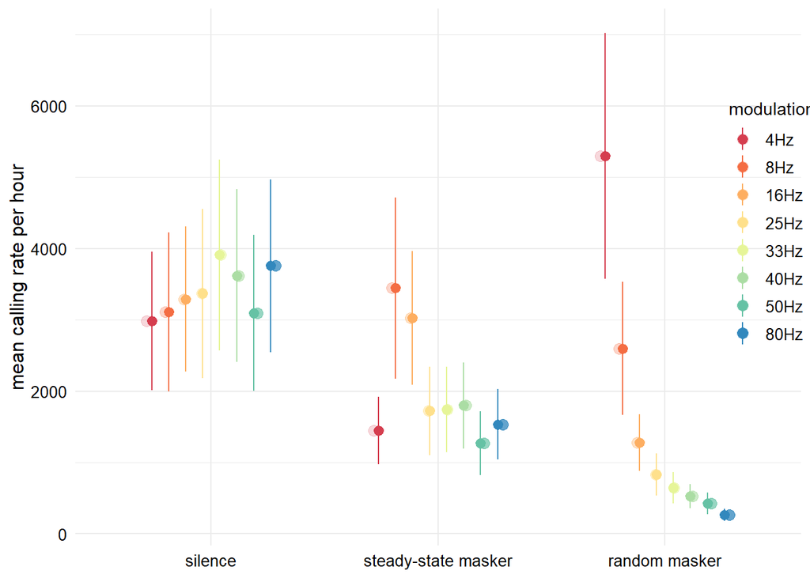

```r
preds <- do.call(rbind, lapply(all.models, '[[', 'predictions')) %>%
   mutate(across(is.numeric, round, 2)) %>%
   mutate(modulation = factor(str_split(row.names(.),"[.]",simplify = T)[,1],
          levels = sort(unique(data$modulation))),.before=1) %>%
   remove_rownames()

n_pred <- p.n_pred(preds) %>% recolor()

n_pred
```

```r
ggsave(file.path(figures_path,paste0(exp, '_fig2d.png') ), n_pred, width = 5, height = 4)
```

### Changes in call rate between modulation rate contexts

Now let’s see if there were changes in the overall rate of calling between different modulation rate contexts for the same playback condition.

```r
all.models2 <- lapply(sort(unique(n_calls_reg$condition)), function(x)
                      md <- run_negbinom_model(n_calls_reg %>% filter(condition==x),
                                               formula = "n ~  modulation",
                                               contformula = "~ modulation")  )
```

```
## [1] "~~~~~~~~~~~~~~  all rates  ~~~~~~~~~~~~~~"
## [1] "Model summary..."
##
## Call:
## MASS::glm.nb(formula = as.formula(formula), data = dat, init.theta = 0.4097400923,
##     link = log)
##
## Deviance Residuals:
##     Min       1Q   Median       3Q      Max
## -2.4104  -1.3337  -0.6802   0.2266   1.4645
##
## Coefficients:
##                Estimate Std. Error z value            Pr(>|z|)
## (Intercept)     8.00027    0.34935  22.900 <0.0000000000000002 ***
## modulation8Hz   0.04216    0.49405   0.085               0.932
## modulation16Hz  0.09791    0.49405   0.198               0.843
## modulation25Hz  0.12245    0.49405   0.248               0.804
## modulation33Hz  0.27076    0.49405   0.548               0.584
## modulation40Hz  0.19421    0.50051   0.388               0.698
## modulation50Hz  0.03818    0.49405   0.077               0.938
## modulation80Hz  0.23116    0.49405   0.468               0.640
## ---
## Signif. codes:  0 '***' 0.001 '**' 0.01 '*' 0.05 '.' 0.1 ' ' 1
##
## (Dispersion parameter for Negative Binomial(0.4097) family taken to be 1)
##
##     Null deviance: 208.15  on 158  degrees of freedom
## Residual deviance: 207.59  on 151  degrees of freedom
## AIC: 2794.7
##
## Number of Fisher Scoring iterations: 1
##
##
##               Theta:  0.4097
##           Std. Err.:  0.0374
##
##  2 x log-likelihood:  -2776.6580
## [1] "Model dispersion..."
## [1] 0.7875016
## [1] "Type II Deviance Table..."
```

[output cut: 258 more lines]

```
##  16Hz / 50Hz  3.01 1.294 Inf    1   2.562  0.2912
##  16Hz / 80Hz  4.86 2.089 Inf    1   3.674  0.0067
##  25Hz / 33Hz  1.29 0.556 Inf    1   0.599  1.0000
##  25Hz / 40Hz  1.58 0.678 Inf    1   1.058  1.0000
##  25Hz / 50Hz  1.96 0.841 Inf    1   1.560  1.0000
##  25Hz / 80Hz  3.16 1.357 Inf    1   2.672  0.2112
##  33Hz / 40Hz  1.22 0.524 Inf    1   0.459  1.0000
##  33Hz / 50Hz  1.51 0.650 Inf    1   0.961  1.0000
##  33Hz / 80Hz  2.44 1.049 Inf    1   2.073  1.0000
##  40Hz / 50Hz  1.24 0.534 Inf    1   0.502  1.0000
##  40Hz / 80Hz  2.00 0.861 Inf    1   1.614  1.0000
##  50Hz / 80Hz  1.61 0.694 Inf    1   1.112  1.0000
##
## P value adjustment: bonferroni method for 28 tests
## Tests are performed on the log scale
```

```r
names(all.models2) <- sort(unique(n_calls_reg$condition))
```

#### Anova

```r
# pull out anova tables
(anova2 <- do.call(rbind, lapply(all.models2, '[[', 'deviance')) %>%
   mutate(across(is.numeric, round, 2)))
```

```
##                     LR Chisq Df Pr(>Chisq)
## silence                 0.56  7       1.00
## steady-state masker     7.34  7       0.39
## random masker          81.08  7       0.00
```

#### Marginal mean contrasts

```
##             modulation    contrast   IRR   se asymp_lcl asymp_ucl z_ratio p_value
## 1              silence   4Hz / 8Hz  0.96 0.47      0.20      4.49   -0.09    1.00
## 2              silence  4Hz / 16Hz  0.91 0.45      0.19      4.24   -0.20    1.00
## 3              silence  4Hz / 25Hz  0.88 0.44      0.19      4.14   -0.25    1.00
## 4              silence  4Hz / 33Hz  0.76 0.38      0.16      3.57   -0.55    1.00
## 5              silence  4Hz / 40Hz  0.82 0.41      0.17      3.93   -0.39    1.00
## 6              silence  4Hz / 50Hz  0.96 0.48      0.21      4.50   -0.08    1.00
## 7              silence  4Hz / 80Hz  0.79 0.39      0.17      3.71   -0.47    1.00
## 8              silence  8Hz / 16Hz  0.95 0.47      0.20      4.43   -0.11    1.00
## 9              silence  8Hz / 25Hz  0.92 0.46      0.20      4.32   -0.16    1.00
## 10             silence  8Hz / 33Hz  0.80 0.39      0.17      3.72   -0.46    1.00
## 11             silence  8Hz / 40Hz  0.86 0.43      0.18      4.10   -0.30    1.00
## 12             silence  8Hz / 50Hz  1.00 0.50      0.22      4.70    0.01    1.00
## 13             silence  8Hz / 80Hz  0.83 0.41      0.18      3.87   -0.38    1.00
## 14             silence 16Hz / 25Hz  0.98 0.48      0.21      4.57   -0.05    1.00
```

[output cut: 70 more lines]

#### Incidence Rate Ratios (IRR)

```r
# IRR
IRRs2 <- do.call(rbind, lapply(all.models2, '[[', 'IRR')) %>%
   mutate(across(is.numeric, round, 2)) %>%
   mutate(condition = str_split(row.names(.),"[.]",simplify = T)[,1], .before=1) %>%
   mutate(coef = str_remove(str_split(row.names(.),"[.]",simplify = T)[,2],"condition"), .after=1) %>%
   remove_rownames()
IRRs2
```

```
##              condition           coef Estimate   2.5 %   97.5 %
## 1              silence    (Intercept)  2981.75 1612.60  6456.97
## 2              silence  modulation8Hz     1.04    0.39     2.80
## 3              silence modulation16Hz     1.10    0.41     2.96
## 4              silence modulation25Hz     1.13    0.42     3.03
## 5              silence modulation33Hz     1.31    0.49     3.52
## 6              silence modulation40Hz     1.21    0.45     3.32
## 7              silence modulation50Hz     1.04    0.39     2.79
## 8              silence modulation80Hz     1.26    0.47     3.38
## 9  steady-state masker    (Intercept)  1446.90  776.51  3171.48
## 10 steady-state masker  modulation8Hz     2.38    0.87     6.60
## 11 steady-state masker modulation16Hz     2.09    0.77     5.69
## 12 steady-state masker modulation25Hz     1.19    0.43     3.30
## 13 steady-state masker modulation33Hz     1.20    0.44     3.28
## 14 steady-state masker modulation40Hz     1.24    0.45     3.45
## 15 steady-state masker modulation50Hz     0.88    0.32     2.39
## 16 steady-state masker modulation80Hz     1.06    0.39     2.89
## 17       random masker    (Intercept)  5299.50 3082.25 10267.18
## 18       random masker  modulation8Hz     0.49    0.21     1.15
## 19       random masker modulation16Hz     0.24    0.10     0.57
## 20       random masker modulation25Hz     0.16    0.07     0.37
## 21       random masker modulation33Hz     0.12    0.05     0.28
## 22       random masker modulation40Hz     0.10    0.04     0.23
## 23       random masker modulation50Hz     0.08    0.03     0.19
## 24       random masker modulation80Hz     0.05    0.02     0.12
```

### Anticipating the trough or the peak?

Use bootstrapped means from the whole data set, we now want to see whether average call onsets were “aimed” more at dodging AM peaks or more targeted at AM troughs.

Plot timings relative to both acoustic features. Show raw data (dots), distributions, and boxplots.

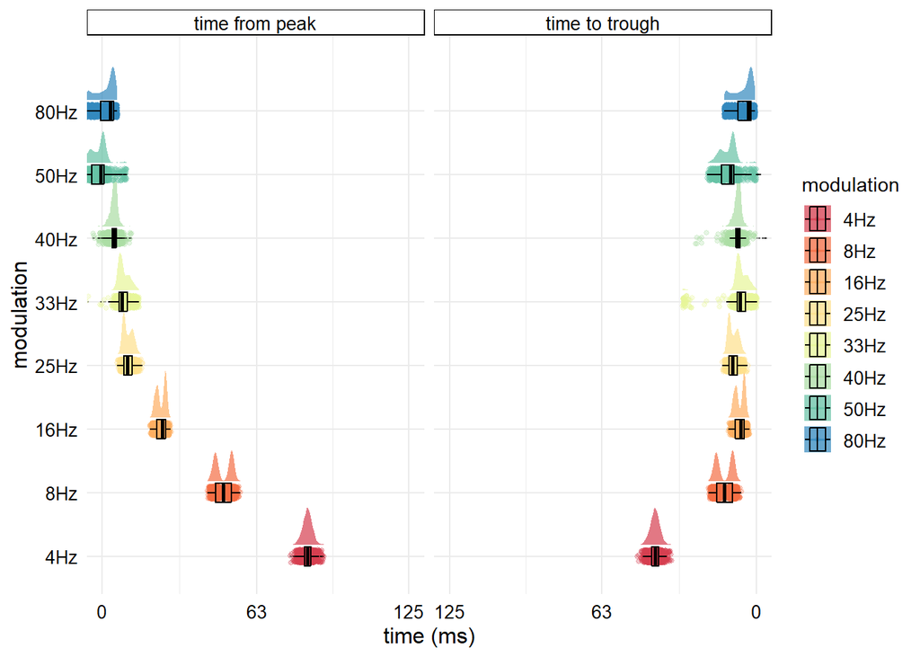

```r
comp.plot <- p.composite_peak_trough(mu_bs_time)

print(comp.plot)
```

```r
curve_plots <- p.curves(mu_bs_time)

ggsave(file.path(figures_path,paste0(exp, '_fig4a.png')), comp.plot, width = w2+2, height = h-2)
ggsave(file.path(figures_path,paste0(exp, '_fig4a_curve.png')), curve_plots[[1]], width = (w2+2/2), height = h-2)
```

```r
# timings by condition and modulation
more_timings <- mu_bs_time %>% group_by(modulation, condition) %>%
  summarise(median_peak = median(t_from_peak)*1000,
           iqr_peak = IQR(t_from_peak)*1000,
           #mad_peak = mad(t_from_peak),
           median_trough = median(t_to_trough)*1000,
           #mad_trough = mad(t_to_trough),
           iqr_trough = IQR(t_to_trough)*1000) %>%
  mutate(across(where(is.numeric),round,1))


more_timings
```

```
## # A tibble: 16 × 6
## # Groups:   modulation [8]
##    modulation condition           median_peak iqr_peak median_trough iqr_trough
##    <fct>      <fct>                     <dbl>    <dbl>         <dbl>      <dbl>
##  1 4Hz        steady-state masker        83.7      3.1          41.3        3.1
##  2 4Hz        random masker              83.7      2.1          41.3        2.1
##  3 8Hz        steady-state masker        52.8      1.3           9.7        1.3
##  4 8Hz        random masker              46.2      1.4          16.3        1.4
##  5 16Hz       steady-state masker        25.8      0.9           5          0.9
##  6 16Hz       random masker              22.3      1.4           8.5        1.4
##  7 25Hz       steady-state masker         8.9      1            11.1        1
##  8 25Hz       random masker              12.2      1.7           7.8        1.7
##  9 33Hz       steady-state masker        10.3      3.1           4.5        3.1
## 10 33Hz       random masker               7.3      1.3           7.5        1.3
## 11 40Hz       steady-state masker         5.3      1.1           7.2        1.1
## 12 40Hz       random masker               4.4      2.3           8.1        2.3
## 13 50Hz       steady-state masker         0.5      1.4           9.5        1.4
## 14 50Hz       random masker              -4.1      3.4          14.1        3.4
## 15 80Hz       steady-state masker         4.2      1.8           2.4        1.8
## 16 80Hz       random masker               0.7      5.8           6          5.8
```

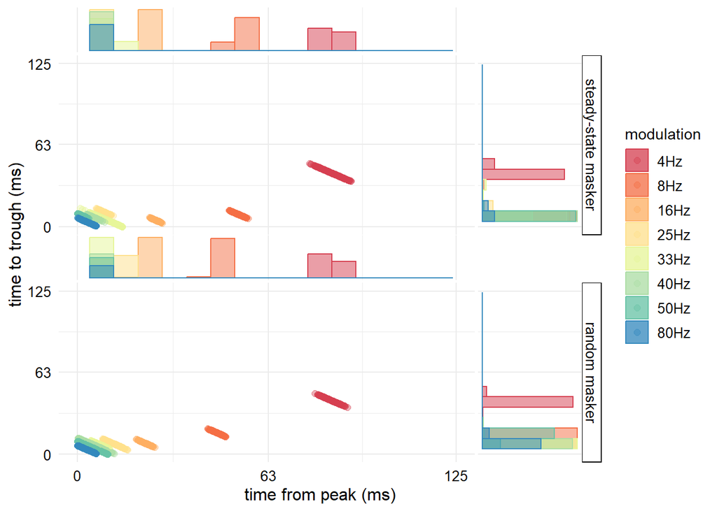

```r
pb <- p.peak_trough(mu_bs_time %>%
                      dplyr::filter(!condition=="silence", !condition=="half-band masker"), binwidth = 8) %>%
  recolor()

print(pb)
```

```r
ggsave(file.path(figures_path,paste0(exp, '_fig4a-alt1.png')), pb, width = 6, height = 4)
```

### Linear Classifiers

```r
mu_ld <- mu_bs_time %>%
  dplyr::select(t_to_trough, t_from_peak, modulation)
mu_ld <- mu_ld %>%
  mutate(modulation = make.names(mu_ld$modulation) %>% as_factor())

# split into 0.6:0.4 train/validation set
set.seed(seed)
#train_idx <- sample(1:nrow(mu_ld), size = floor(nrow(mu_ld)*0.60))
train_idx <- createDataPartition(mu_ld$modulation, p = .6, list = FALSE)

mu_bs_train <- mu_ld[train_idx,]
mu_bs_valid <- mu_ld[-train_idx,]


# cross-val
ctrl <- trainControl(method = "repeatedcv", 10, repeats = 10,
                     summaryFunction = multiClassSummary, classProbs = TRUE, savePredictions = TRUE)
```

First train some LDA models on troughs only, peaks only, or both:

```r
#--- Trough
trough_lda <- train(mu_bs_train[,1,drop=FALSE], mu_bs_train$modulation,
                    method = "lda", trControl = ctrl, preProcess = c("center", "scale"))

##Generate LDA model predictions for bio indicator test set
trough_lda_pred <- predict(trough_lda, mu_bs_valid[,-3])

##Generate confusion matrix to show results
trough_lda_mat <- confusionMatrix(trough_lda_pred, mu_bs_valid$modulation)#, positive = "No")
trough_lda_mat
```

```
## Confusion Matrix and Statistics
##
##           Reference
## Prediction X4Hz X8Hz X16Hz X25Hz X33Hz X40Hz X50Hz X80Hz
##      X4Hz   800    0     0     0    14     0     0     0
##      X8Hz     0  405     0    32     6     6   291    39
##      X16Hz    0    3    27    48    83   122     8    18
##      X25Hz    0  266   185   176    61   142   293    47
##      X33Hz    0    1    34    45    97   117     3    35
##      X40Hz    0   41   187   155   228   323    63    37
##      X50Hz    0   84     7   325     1    33   113    65
##      X80Hz    0    0   360    19   310    57    29   559
##
## Overall Statistics
##
##                Accuracy : 0.3906
##                  95% CI : (0.3786, 0.4027)
##     No Information Rate : 0.125
##     P-Value [Acc > NIR] : < 0.00000000000000022
##
##                   Kappa : 0.3036
##
##  Mcnemar's Test P-Value : NA
##
## Statistics by Class:
##
##                      Class: X4Hz Class: X8Hz Class: X16Hz Class: X25Hz Class: X33Hz Class: X40Hz Class: X50Hz Class: X80Hz
## Sensitivity               1.0000     0.50625     0.033750       0.2200      0.12125      0.40375      0.14125      0.69875
## Specificity               0.9975     0.93321     0.949643       0.8225      0.95804      0.87304      0.90804      0.86161
## Pos Pred Value            0.9828     0.51990     0.087379       0.1504      0.29217      0.31238      0.17994      0.41904
## Neg Pred Value            1.0000     0.92973     0.873091       0.8807      0.88415      0.91111      0.88098      0.95243
## Prevalence                0.1250     0.12500     0.125000       0.1250      0.12500      0.12500      0.12500      0.12500
## Detection Rate            0.1250     0.06328     0.004219       0.0275      0.01516      0.05047      0.01766      0.08734
## Detection Prevalence      0.1272     0.12172     0.048281       0.1828      0.05187      0.16156      0.09813      0.20844
## Balanced Accuracy         0.9988     0.71973     0.491696       0.5212      0.53964      0.63839      0.52464      0.78018
```

```r
#--- Peak
peak_lda <- train(mu_bs_train[,2,drop=FALSE], mu_bs_train$modulation,
                  method = "lda", trControl = ctrl, preProcess = c("center", "scale"))

##Generate LDA model predictions for bio indicator test set
peak_lda_pred <- predict(peak_lda, mu_bs_valid[,-3])

##Generate confusion matrix to show results
peak_lda_mat <- confusionMatrix(peak_lda_pred, mu_bs_valid$modulation) #, positive = "No")
peak_lda_mat
```

```
## Confusion Matrix and Statistics
##
##           Reference
## Prediction X4Hz X8Hz X16Hz X25Hz X33Hz X40Hz X50Hz X80Hz
##      X4Hz   800    0     0     0     0     0     0     0
##      X8Hz     0  800     0     0     0     0     0     0
##      X16Hz    0    0   800     0     0     0     0     0
##      X25Hz    0    0     0   477   280     5     6     0
##      X33Hz    0    0     0   320   407    57    13     0
##      X40Hz    0    0     0     3    93   634    15   421
##      X50Hz    0    0     0     0    19     6   478   206
##      X80Hz    0    0     0     0     1    98   288   173
##
## Overall Statistics
##
##                Accuracy : 0.7139
##                  95% CI : (0.7027, 0.725)
##     No Information Rate : 0.125
##     P-Value [Acc > NIR] : < 0.00000000000000022
##
##                   Kappa : 0.673
##
##  Mcnemar's Test P-Value : NA
##
## Statistics by Class:
##
##                      Class: X4Hz Class: X8Hz Class: X16Hz Class: X25Hz Class: X33Hz Class: X40Hz Class: X50Hz Class: X80Hz
## Sensitivity                1.000       1.000        1.000      0.59625      0.50875      0.79250      0.59750      0.21625
## Specificity                1.000       1.000        1.000      0.94804      0.93036      0.90500      0.95875      0.93089
## Pos Pred Value             1.000       1.000        1.000      0.62109      0.51066      0.54374      0.67419      0.30893
## Neg Pred Value             1.000       1.000        1.000      0.94265      0.92986      0.96828      0.94342      0.89264
## Prevalence                 0.125       0.125        0.125      0.12500      0.12500      0.12500      0.12500      0.12500
## Detection Rate             0.125       0.125        0.125      0.07453      0.06359      0.09906      0.07469      0.02703
## Detection Prevalence       0.125       0.125        0.125      0.12000      0.12453      0.18219      0.11078      0.08750
## Balanced Accuracy          1.000       1.000        1.000      0.77214      0.71955      0.84875      0.77812      0.57357
```

```r
#--- Peak
full_lda <- train(mu_bs_train[,-3], mu_bs_train$modulation,
                  method = "lda", trControl = ctrl, preProcess = c("center", "scale"))

##Generate LDA model predictions for bio indicator test set
full_lda_pred <- predict(full_lda, mu_bs_valid[,-3])

##Generate confusion matrix to show results
full_lda_mat <- confusionMatrix(full_lda_pred, mu_bs_valid$modulation) #, positive = "No")
full_lda_mat
```

```
## Confusion Matrix and Statistics
##
##           Reference
## Prediction X4Hz X8Hz X16Hz X25Hz X33Hz X40Hz X50Hz X80Hz
##      X4Hz   633  384     0     0     0     0     0     0
##      X8Hz   167  378     0     0     0     0     0     0
##      X16Hz    0   38   795     8    75     3     4     0
##      X25Hz    0    0     0   105   201   131     5   138
##      X33Hz    0    0     5   330   348    40    19   313
##      X40Hz    0    0     0   244   121   312     4    71
##      X50Hz    0    0     0     0    20    44   632   171
##      X80Hz    0    0     0   113    35   270   136   107
##
## Overall Statistics
##
##                Accuracy : 0.5172
##                  95% CI : (0.5049, 0.5295)
##     No Information Rate : 0.125
##     P-Value [Acc > NIR] : < 0.00000000000000022
##
##                   Kappa : 0.4482
##
##  Mcnemar's Test P-Value : NA
##
## Statistics by Class:
##
##                      Class: X4Hz Class: X8Hz Class: X16Hz Class: X25Hz Class: X33Hz Class: X40Hz Class: X50Hz Class: X80Hz
## Sensitivity              0.79125     0.47250       0.9938      0.13125      0.43500      0.39000      0.79000      0.13375
## Specificity              0.93143     0.97018       0.9771      0.91518      0.87375      0.92143      0.95804      0.90107
## Pos Pred Value           0.62242     0.69358       0.8613      0.18103      0.32986      0.41489      0.72895      0.16188
## Neg Pred Value           0.96898     0.92792       0.9991      0.88058      0.91543      0.91360      0.96964      0.87925
## Prevalence               0.12500     0.12500       0.1250      0.12500      0.12500      0.12500      0.12500      0.12500
## Detection Rate           0.09891     0.05906       0.1242      0.01641      0.05437      0.04875      0.09875      0.01672
## Detection Prevalence     0.15891     0.08516       0.1442      0.09062      0.16484      0.11750      0.13547      0.10328
## Balanced Accuracy        0.86134     0.72134       0.9854      0.52321      0.65438      0.65571      0.87402      0.51741
```

```r
lda_validation <- list(full_lda_mat, trough_lda_mat, peak_lda_mat)
```

Compare models

```r
results <- resamples(list(full=full_lda, trough=trough_lda, peak=peak_lda))

# ggplot(results) +
#    labs(y = "Accuracy") +
#    theme_linedraw()
# trellis.par.set(caretTheme())
# dotplot(results, metric = "Sensitivity")

summary(results)
```

```
##
## Call:
## summary.resamples(object = results)
##
## Models: full, trough, peak
## Number of resamples: 100
##
## Accuracy
##             Min.   1st Qu.    Median      Mean   3rd Qu.      Max. NA's
## full   0.4802083 0.5018229 0.5083333 0.5089583 0.5158854 0.5427083    0
## trough 0.3510417 0.3760417 0.3843750 0.3839896 0.3916667 0.4156250    0
## peak   0.6947917 0.7135417 0.7187500 0.7210833 0.7283854 0.7510417    0
##
## AUC
##             Min.   1st Qu.    Median      Mean   3rd Qu.      Max. NA's
## full   0.8780016 0.8840352 0.8865287 0.8862439 0.8883840 0.8954557    0
## trough 0.8158736 0.8277607 0.8313483 0.8308003 0.8347349 0.8455171    0
## peak   0.9443676 0.9488145 0.9500267 0.9506253 0.9526972 0.9577567    0
##
## Kappa
##             Min.   1st Qu.    Median      Mean   3rd Qu.      Max. NA's
## full   0.4059524 0.4306548 0.4380952 0.4388095 0.4467262 0.4773810    0
## trough 0.2583333 0.2869048 0.2964286 0.2959881 0.3047619 0.3321429    0
## peak   0.6511905 0.6726190 0.6785714 0.6812381 0.6895833 0.7154762    0
##
## logLoss
##             Min.   1st Qu.    Median      Mean  3rd Qu.      Max. NA's
## full   1.0158496 1.0510726 1.0695536 1.0724155 1.091012 1.1506466    0
## trough 1.3870035 1.4484412 1.4802275 1.4744692 1.497029 1.5734467    0
## peak   0.5977412 0.6443237 0.6662122 0.6699696 0.699831 0.7451066    0
##
## Mean_Balanced_Accuracy
##             Min.   1st Qu.    Median      Mean   3rd Qu.      Max. NA's
## full   0.7029762 0.7153274 0.7190476 0.7194048 0.7233631 0.7386905    0
## trough 0.6291667 0.6434524 0.6482143 0.6479940 0.6523810 0.6660714    0
## peak   0.8255952 0.8363095 0.8392857 0.8406190 0.8447917 0.8577381    0
##
## Mean_Detection_Rate
##              Min.    1st Qu.     Median       Mean    3rd Qu.       Max. NA's
## full   0.06002604 0.06272786 0.06354167 0.06361979 0.06448568 0.06783854    0
```

[output cut: 35 more lines]

```
## full   0.4802083 0.5018229 0.5083333 0.5089583 0.5158854 0.5427083    0
## trough 0.3510417 0.3760417 0.3843750 0.3839896 0.3916667 0.4156250    0
## peak   0.6947917 0.7135417 0.7187500 0.7210833 0.7283854 0.7510417    0
##
## Mean_Specificity
##             Min.   1st Qu.    Median      Mean   3rd Qu.      Max. NA's
## full   0.9257440 0.9288318 0.9297619 0.9298512 0.9308408 0.9346726    0
## trough 0.9072917 0.9108631 0.9120536 0.9119985 0.9130952 0.9165179    0
## peak   0.9563988 0.9590774 0.9598214 0.9601548 0.9611979 0.9644345    0
##
## prAUC
##             Min.   1st Qu.    Median      Mean   3rd Qu.      Max. NA's
## full   0.5156668 0.5321144 0.5398414 0.5385769 0.5447830 0.5590369    0
## trough 0.3084944 0.3257429 0.3351581 0.3337714 0.3407883 0.3585792    0
## peak   0.4840272 0.5008613 0.5102298 0.5090150 0.5169973 0.5404702    0
```

Stats comparisons

```r
# compare stats
difValues <- diff(results)
summary(difValues)
```

```
##
## Call:
## summary.diff.resamples(object = difValues)
##
## p-value adjustment: bonferroni
## Upper diagonal: estimates of the difference
## Lower diagonal: p-value for H0: difference = 0
##
## Accuracy
##        full                  trough                peak
## full                          0.1250               -0.2121
## trough < 0.00000000000000022                       -0.3371
## peak   < 0.00000000000000022 < 0.00000000000000022
##
## AUC
##        full                  trough                peak
## full                          0.05544              -0.06438
## trough < 0.00000000000000022                       -0.11982
## peak   < 0.00000000000000022 < 0.00000000000000022
##
## Kappa
##        full                  trough                peak
## full                          0.1428               -0.2424
## trough < 0.00000000000000022                       -0.3853
## peak   < 0.00000000000000022 < 0.00000000000000022
##
## logLoss
##        full                  trough                peak
## full                         -0.4021                0.4024
## trough < 0.00000000000000022                        0.8045
## peak   < 0.00000000000000022 < 0.00000000000000022
##
## Mean_Balanced_Accuracy
##        full                  trough                peak
## full                          0.07141              -0.12121
## trough < 0.00000000000000022                       -0.19262
## peak   < 0.00000000000000022 < 0.00000000000000022
##
## Mean_Detection_Rate
##        full                  trough                peak
```

[output cut: 36 more lines]

```
## full                          0.1250               -0.2121
## trough < 0.00000000000000022                       -0.3371
## peak   < 0.00000000000000022 < 0.00000000000000022
##
## Mean_Specificity
##        full                  trough                peak
## full                          0.01785              -0.03030
## trough < 0.00000000000000022                       -0.04816
## peak   < 0.00000000000000022 < 0.00000000000000022
##
## prAUC
##        full                  trough                peak
## full                          0.20481               0.02956
## trough < 0.00000000000000022                       -0.17524
## peak   < 0.00000000000000022 < 0.00000000000000022
```

```r
res <- evalm(list(full_lda, trough_lda, peak_lda),gnames=c('full','trough','peak'), rlinethick = 0.8)
```

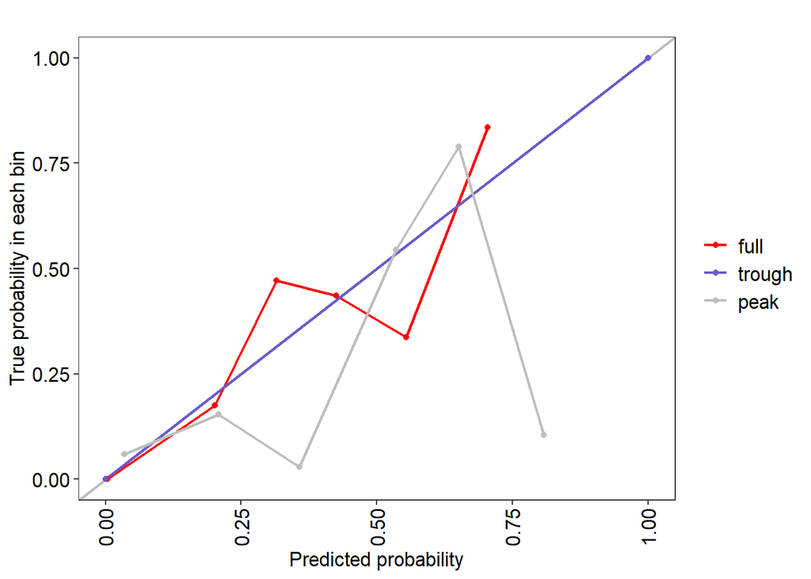

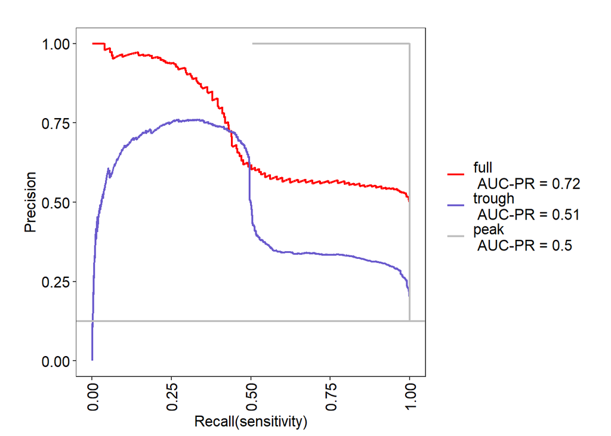

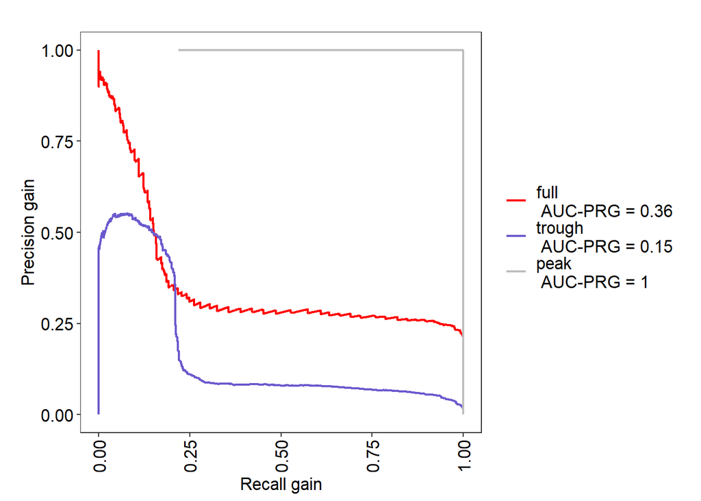

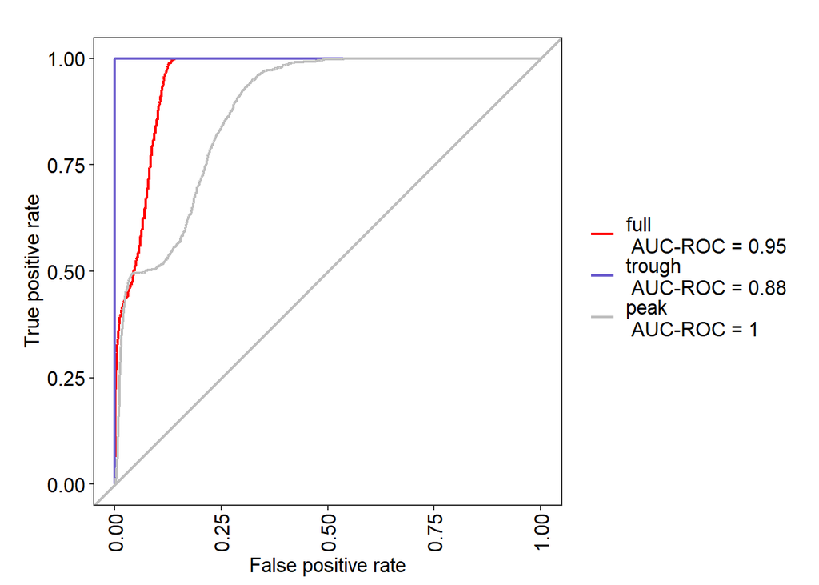

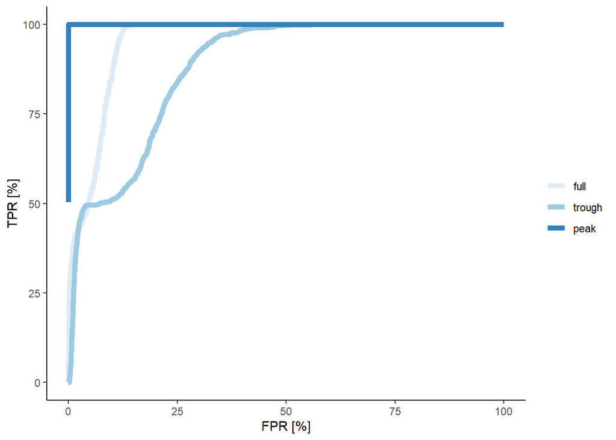

```r
pr <-
  ggplot(res$prg$data) +
  geom_line(aes(x = FPR*100, y = SENS*100, color = Group), size = 2) +
  scale_color_brewer(name = NULL, expand = c(0,0)) +
  labs(x = "FPR [%]", y = "TPR [%]") +
  theme_jamlight() +
  theme_classic() +
  theme(panel.border = element_blank(),
      panel.spacing.y = unit(0.3, "cm"))
pr
```

```r
  ggsave(file.path(figures_path,paste0(exp, '_fig4e.png')),
         pr, width = 5, height = 4)
```

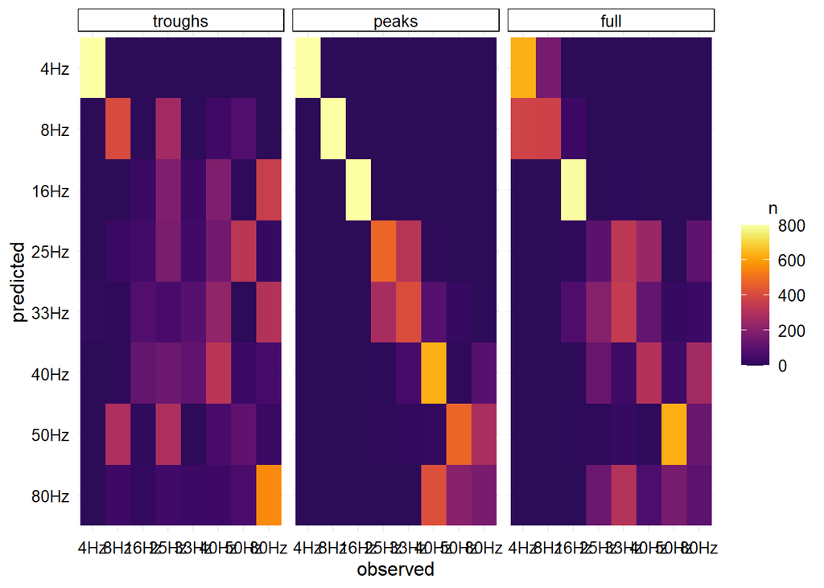

```r
confmats <- lapply(lda_validation, function(x)
  cormat_to_df(x$table %>% as.data.frame() %>%
                  mutate(Prediction = as_factor(str_remove(Prediction,"X")),
                         Reference = as_factor(str_remove(Reference, "X")))) ) %>%
  setNames(c("full", "troughs", "peaks")) %>%
  map_df(., ~as.data.frame(.x), .id="model") %>%
  mutate(model = factor(model, levels = c("troughs", "peaks", "full")))


confmat <- p.mat(confmats, ulim = max((mu_bs_valid%>%group_by(modulation)%>%summarise(n=n()))[,2])) +
  facet_grid(cols=vars(model))
  print(confmat)
```

```r
  ggsave(file.path(figures_path,paste0(exp, '_fig4b.png')),
         confmat, width = w2, height = h)
```

### Quantify overlapping calls

```r
overlap_calls <- data[which(data$onset_interval<data$duration),]%>%
  mutate(overlap = duration-onset_interval)

cat("Of a total of", nrow(data), "calls,", nrow(overlap_calls),
    "(", round(nrow(overlap_calls)/nrow(data)*100,2), "%) overlapped in time.")
```

```
## Of a total of 1088994 calls, 31942 ( 2.93 %) overlapped in time.
```

```r
n_overlap <- overlap_calls %>% group_by(modulation, condition) %>% summarise(n = n())

(n_overlap_conttable <- addmargins(table(overlap_calls$modulation,overlap_calls$condition), c(1,2)))
```

```
##
##        silence steady-state masker random masker   Sum
##   4Hz     3514                 406          1331  5251
##   8Hz     3461                1322           603  5386
##   16Hz    2452                 847           330  3629
##   25Hz    3278                 383           221  3882
##   33Hz    3506                 345           164  4015
##   40Hz    2988                 338           130  3456
##   50Hz    3017                 219            99  3335
##   80Hz    2687                 233            68  2988
##   Sum    24903                4093          2946 31942
```

#### Modelling call overlap incidence

Let’s run the overlap data through a negative binomial…

Deviance tables…

```r
(ovlp.anova <- do.call(rbind, lapply(ovlp.models, '[[', 'deviance')) %>%
   mutate(across(is.numeric, round, 2)))
```

```
##            LR Chisq Df Pr(>Chisq)
## condition      5.23  2       0.07
## condition1     7.27  2       0.03
## condition2    12.19  2       0.00
## condition3    15.20  2       0.00
## condition4    25.20  2       0.00
## condition5    31.39  2       0.00
## condition6    34.76  2       0.00
## condition7    35.55  2       0.00
```

And contrasts…

```r
(contrasts <- do.call(rbind, lapply(ovlp.models, '[[', 'contrasts')) %>%
   mutate(across(is.numeric, round, 2)) %>%
   mutate(modulation = factor(rep(unique(n_overlap$modulation),each=length(unique(n_overlap$condition)))),.before=1) %>%
   remove_rownames() %>%
   dplyr::select(-c("df", "null")) %>%
   dplyr::rename(IRR = ratio))
```

```
##    modulation                     masking_condition   IRR    se asymp_lcl asymp_ucl z_ratio p_value
## 1         4Hz       silence / (steady-state masker)  4.58  3.04      0.94     22.45    2.29    0.07
## 2         4Hz               silence / random masker  2.33  1.33      0.60      9.11    1.49    0.41
## 3         4Hz (steady-state masker) / random masker  0.51  0.34      0.10      2.58   -1.00    0.96
## 4         8Hz       silence / (steady-state masker)  1.92  1.21      0.43      8.65    1.04    0.90
## 5         8Hz               silence / random masker  5.36  3.16      1.31     21.96    2.85    0.01
## 6         8Hz (steady-state masker) / random masker  2.79  1.78      0.60     12.88    1.61    0.32
## 7        16Hz       silence / (steady-state masker)  2.21  1.16      0.63      7.77    1.52    0.39
## 8        16Hz               silence / random masker  6.56  3.32      1.95     22.02    3.72    0.00
## 9        16Hz (steady-state masker) / random masker  2.96  1.60      0.81     10.83    2.00    0.14
## 10       25Hz       silence / (steady-state masker)  5.14  3.10      1.21     21.80    2.71    0.02
## 11       25Hz               silence / random masker  9.89  5.80      2.43     40.26    3.91    0.00
## 12       25Hz (steady-state masker) / random masker  1.93  1.27      0.40      9.37    0.99    0.96
## 13       33Hz       silence / (steady-state masker)  5.72  3.07      1.58     20.69    3.24    0.00
## 14       33Hz               silence / random masker 14.70  7.47      4.35     49.66    5.28    0.00
## 15       33Hz (steady-state masker) / random masker  2.57  1.50      0.64     10.41    1.62    0.32
## 16       40Hz       silence / (steady-state masker)  6.48  3.29      1.92     21.87    3.68    0.00
## 17       40Hz               silence / random masker 18.39  9.20      5.55     60.93    5.82    0.00
## 18       40Hz (steady-state masker) / random masker  2.84  1.53      0.78     10.35    1.93    0.16
## 19       50Hz       silence / (steady-state masker) 11.27  6.43      2.88     44.16    4.25    0.00
## 20       50Hz               silence / random masker 27.70 15.51      7.26    105.80    5.93    0.00
## 21       50Hz (steady-state masker) / random masker  2.46  1.45      0.60     10.12    1.52    0.38
## 22       80Hz       silence / (steady-state masker)  7.69  3.88      2.30     25.73    4.04    0.00
## 23       80Hz               silence / random masker 26.34 13.56      7.68     90.35    6.35    0.00
## 24       80Hz (steady-state masker) / random masker  3.43  1.94      0.89     13.24    2.18    0.09
```

And finally, predict values…

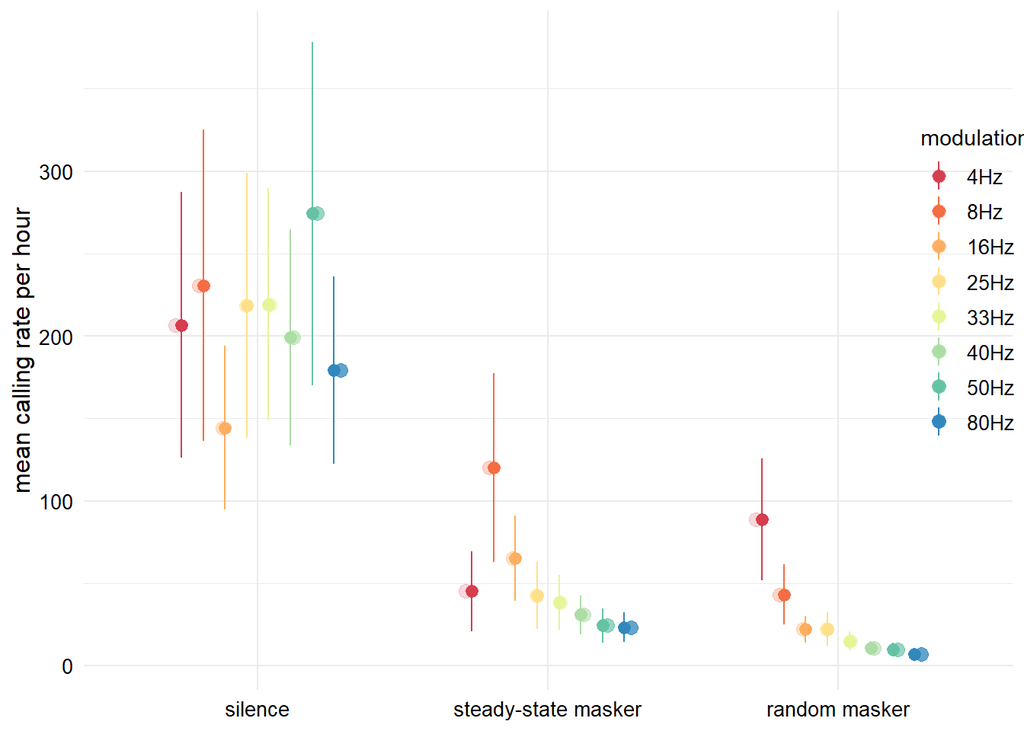

```r
ovlp_preds <- do.call(rbind, lapply(ovlp.models, '[[', 'predictions')) %>%
   mutate(across(is.numeric, round, 2)) %>%
   mutate(modulation = factor(rep(unique(n_overlap$modulation),each=length(unique(n_overlap$condition))))) %>%
   remove_rownames()

ovlp_pred <- p.n_pred(ovlp_preds) %>% recolor()

ovlp_pred
```

```r
ggsave(file.path(figures_path,paste0(exp, '_figS5b.png') ), ovlp_pred, width = 5, height = 4)
```

Finally, we can calculate circular stats for overlapping calls, and visualize the angular vectors representing those distributions for each condition:

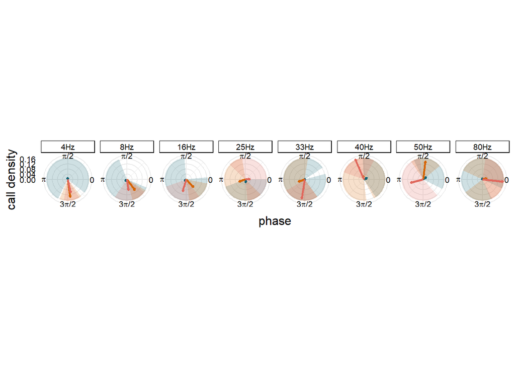

```r
overlap_circsummary <- overlap_calls %>%
    group_by(modulation, condition) %>%
    summarize(n = n(),
           theta_bar = mean.circular(start_phase_circ, na.rm = T),
           r_bar = rho.circular(start_phase_circ, na.rm = T),
           vm = var.circular(start_phase_circ),
           rt = rayleigh.test(start_phase_circ, mu=circular(0))$statistic,
           p = rayleigh.test(start_phase_circ, mu=circular(0))$p.value,
           bs_mu_ci_l = mle.vonmises.bootstrap.ci(start_phase_circ, alpha=.05)$mu.ci[1],
           bs_mu_ci_h = mle.vonmises.bootstrap.ci(start_phase_circ, alpha=.05)$mu.ci[2],) %>%
    mutate(p_adjust = p.adjust(p, method ="bonferroni"), .after = "p") %>%
    mutate(across(where(is.numeric), round, 3))

overlap_circsummary %>%
  kbl(escape = FALSE,
      booktabs = TRUE,
      format = "html",
      caption = "Circular statistics for overlapping calls") %>%
  kable_styling() %>%
  cat(., file = file.path(tables_path,paste0(exp, "_circ_stats_overlap.html")))

p.ang <- p.angular_vectors(overlap_circsummary %>% confint_wrap())

p.ang
```

```r
 ggsave(file.path(figures_path,paste0(exp, '_figsS5a.png') ), p.ang, width = w, height = 4)
```

```r
po <- p.circ_density(dat=overlap_calls, circ_dat=overlap_circsummary %>% confint_wrap(), bins = 30) %>% recolor(which = "f")
  print(po)
```

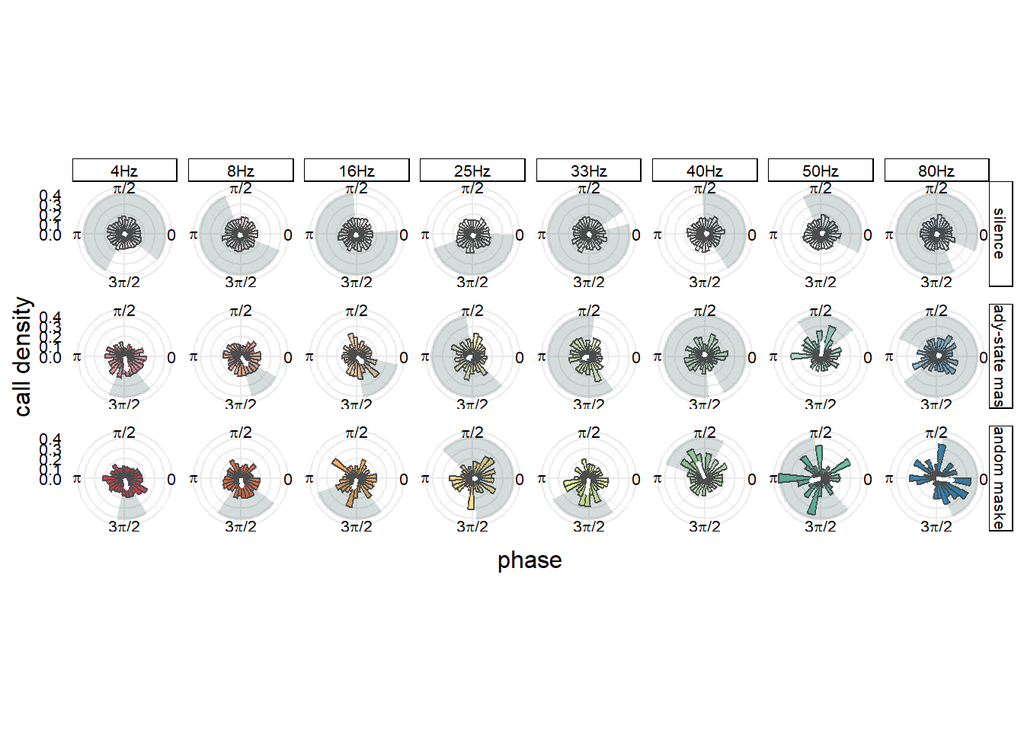

```r
  ggsave(file.path(figures_path,paste0(exp, '_figS5a-alt2.png') ), po, width = w, height = 5)
```

### References

Some references for circular stats can be found in the following books:

- [*Statistical analysis of circular data*](https://books.google.de/books?id=wGPj3EoFdJwC&printsec=frontcover#v=onepage&q&f=false)
- Batschelet, E. (1981). *Circular Statistics in Biology.* Academic Press: London.
- Jammalamadaka, S.R. & Sengupta, A. (2001). *Topics in Circular Statistics.* World Scientific, River Edge, N.J.